# Predict Bike Sharing Demand with AutoGluon Template

## Project: Predict Bike Sharing Demand with AutoGluon

This notebook is a template with each step that you need to complete for the project.

Please fill in your code where there are explicit `?` markers in the notebook. You are welcome to add more cells and code as you see fit.

Once you have completed all the code implementations, please export your notebook as a HTML file so the reviews can view your code. Make sure you have all outputs correctly outputted.

`File-> Export Notebook As... -> Export Notebook as HTML`

There is a writeup to complete as well after all code implememtation is done. Please answer all questions and attach the necessary tables and charts. You can complete the writeup in either markdown or PDF.

Completing the code template and writeup template will cover all of the rubric points for this project.

The rubric contains "Stand Out Suggestions" for enhancing the project beyond the minimum requirements. The stand out suggestions are optional. If you decide to pursue the "stand out suggestions", you can include the code in this notebook and also discuss the results in the writeup file.

## Step 1: Create an account with Kaggle

### Create Kaggle Account and download API key

Below is example of steps to get the API username and key. Each student will have their own username and key.

1. Open account settings.

2. Scroll down to API and click Create New API Token.

3. Open up `kaggle.json` and use the username and key.


## Step 2: Download the Kaggle dataset using the kaggle python library

### Open up Sagemaker Studio and use starter template

1. Notebook should be using a `ml.t3.medium` instance (2 vCPU + 4 GiB)
2. Notebook should be using kernal: `Python 3 (MXNet 1.8 Python 3.7 CPU Optimized)`

### Install packages

```python
import warnings
warnings.filterwarnings('ignore')
```

```python
!pip install -U pip
!pip install -U setuptools wheel
!pip install pydantic==1.10.3
!pip install -U "mxnet<2.0.0" bokeh==2.0.1
!pip install autogluon --no-cache-dir
# Without --no-cache-dir, smaller aws instances may have trouble installing
```

[output not shown]

### Setup Kaggle API Key

```python
!mkdir -p ~/.kaggle
!touch ~/.kaggle/kaggle.json
!chmod 600 ~/.kaggle/kaggle.json
```

```python
import os
import json

# Fill in your Kaggle username and API key
kaggle_username = "kalijohari"
kaggle_key = "b6d8d1f3e4fcceee682ca6f877df67e7"

# Save API token to the kaggle.json file in the home directory
home_dir = os.path.expanduser("~")
kaggle_json_path = os.path.join(home_dir, ".kaggle/kaggle.json")

kaggle_auth = {
    "username": "kalijohari",
    "key": "b6d8d1f3e4fcceee682ca6f877df67e7"
}

# Write the authentication details to the kaggle.json file
with open(kaggle_json_path, "w") as f:
    json.dump(kaggle_auth, f)
```

### Download and explore dataset

### Go to the bike sharing demand competition and agree to the terms

```python
# Download the dataset, it will be in a .zip file so you'll need to unzip it as well.
!kaggle competitions download -c bike-sharing-demand
# If you already downloaded it you can use the -o command to overwrite the file
!unzip -o bike-sharing-demand.zip
```

```
bike-sharing-demand.zip: Skipping, found more recently modified local copy (use --force to force download)
Archive:  bike-sharing-demand.zip
  inflating: sampleSubmission.csv
  inflating: test.csv
  inflating: train.csv
```

```python
import pandas as pd
import numpy as np
from autogluon.tabular import TabularPredictor
```

```python
# Create the train dataset in pandas by reading the csv
# Set the parsing of the datetime column so you can use some of the `dt` features in pandas later
train = pd.read_csv("train.csv",parse_dates=["datetime"])
train.head()
```

|  | datetime | season | holiday | workingday | weather | temp | atemp | humidity | windspeed | casual | registered | count |
| --- | --- | --- | --- | --- | --- | --- | --- | --- | --- | --- | --- | --- |
| 0 | 2011-01-01 00:00:00 | 1 | 0 | 0 | 1 | 9.84 | 14.395 | 81 | 0.0 | 3 | 13 | 16 |
| 1 | 2011-01-01 01:00:00 | 1 | 0 | 0 | 1 | 9.02 | 13.635 | 80 | 0.0 | 8 | 32 | 40 |
| 2 | 2011-01-01 02:00:00 | 1 | 0 | 0 | 1 | 9.02 | 13.635 | 80 | 0.0 | 5 | 27 | 32 |
| 3 | 2011-01-01 03:00:00 | 1 | 0 | 0 | 1 | 9.84 | 14.395 | 75 | 0.0 | 3 | 10 | 13 |
| 4 | 2011-01-01 04:00:00 | 1 | 0 | 0 | 1 | 9.84 | 14.395 | 75 | 0.0 | 0 | 1 | 1 |

```python
# Simple output of the train dataset to view some of the min/max/varition of the dataset features.
train.describe()
```

|  | datetime | season | holiday | workingday | weather | temp | atemp | humidity | windspeed | casual | registered | count |
| --- | --- | --- | --- | --- | --- | --- | --- | --- | --- | --- | --- | --- |
| count | 10886 | 10886.000000 | 10886.000000 | 10886.000000 | 10886.000000 | 10886.00000 | 10886.000000 | 10886.000000 | 10886.000000 | 10886.000000 | 10886.000000 | 10886.000000 |
| mean | 2011-12-27 05:56:22.399411968 | 2.506614 | 0.028569 | 0.680875 | 1.418427 | 20.23086 | 23.655084 | 61.886460 | 12.799395 | 36.021955 | 155.552177 | 191.574132 |
| min | 2011-01-01 00:00:00 | 1.000000 | 0.000000 | 0.000000 | 1.000000 | 0.82000 | 0.760000 | 0.000000 | 0.000000 | 0.000000 | 0.000000 | 1.000000 |
| 25% | 2011-07-02 07:15:00 | 2.000000 | 0.000000 | 0.000000 | 1.000000 | 13.94000 | 16.665000 | 47.000000 | 7.001500 | 4.000000 | 36.000000 | 42.000000 |
| 50% | 2012-01-01 20:30:00 | 3.000000 | 0.000000 | 1.000000 | 1.000000 | 20.50000 | 24.240000 | 62.000000 | 12.998000 | 17.000000 | 118.000000 | 145.000000 |
| 75% | 2012-07-01 12:45:00 | 4.000000 | 0.000000 | 1.000000 | 2.000000 | 26.24000 | 31.060000 | 77.000000 | 16.997900 | 49.000000 | 222.000000 | 284.000000 |
| max | 2012-12-19 23:00:00 | 4.000000 | 1.000000 | 1.000000 | 4.000000 | 41.00000 | 45.455000 | 100.000000 | 56.996900 | 367.000000 | 886.000000 | 977.000000 |
| std | NaN | 1.116174 | 0.166599 | 0.466159 | 0.633839 | 7.79159 | 8.474601 | 19.245033 | 8.164537 | 49.960477 | 151.039033 | 181.144454 |

```python
train.info()
```

```
<class 'pandas.core.frame.DataFrame'>
RangeIndex: 10886 entries, 0 to 10885
Data columns (total 12 columns):
 #   Column      Non-Null Count  Dtype
---  ------      --------------  -----
 0   datetime    10886 non-null  datetime64[ns]
 1   season      10886 non-null  int64
 2   holiday     10886 non-null  int64
 3   workingday  10886 non-null  int64
 4   weather     10886 non-null  int64
 5   temp        10886 non-null  float64
 6   atemp       10886 non-null  float64
 7   humidity    10886 non-null  int64
 8   windspeed   10886 non-null  float64
 9   casual      10886 non-null  int64
 10  registered  10886 non-null  int64
 11  count       10886 non-null  int64
dtypes: datetime64[ns](1), float64(3), int64(8)
memory usage: 1020.7 KB
```

```python
# Checking null values in training data
train.isnull().sum()
```

```
datetime      0
season        0
holiday       0
workingday    0
weather       0
temp          0
atemp         0
humidity      0
windspeed     0
casual        0
registered    0
count         0
dtype: int64
```

```python
# Create the test pandas dataframe in pandas by reading the csv, remember to parse the datetime!
test = pd.read_csv("test.csv",parse_dates=["datetime"])
test.head()
```

|  | datetime | season | holiday | workingday | weather | temp | atemp | humidity | windspeed |
| --- | --- | --- | --- | --- | --- | --- | --- | --- | --- |
| 0 | 2011-01-20 00:00:00 | 1 | 0 | 1 | 1 | 10.66 | 11.365 | 56 | 26.0027 |
| 1 | 2011-01-20 01:00:00 | 1 | 0 | 1 | 1 | 10.66 | 13.635 | 56 | 0.0000 |
| 2 | 2011-01-20 02:00:00 | 1 | 0 | 1 | 1 | 10.66 | 13.635 | 56 | 0.0000 |
| 3 | 2011-01-20 03:00:00 | 1 | 0 | 1 | 1 | 10.66 | 12.880 | 56 | 11.0014 |
| 4 | 2011-01-20 04:00:00 | 1 | 0 | 1 | 1 | 10.66 | 12.880 | 56 | 11.0014 |

```python
# Checking null values in testing data
test.isnull().sum()
```

```
datetime      0
season        0
holiday       0
workingday    0
weather       0
temp          0
atemp         0
humidity      0
windspeed     0
dtype: int64
```

```python
# Shape of train and test datasets
print("Train Dataset Shape : ", train.shape)
print("Test Dataset Shape  : ", test.shape)
```

```
Train Dataset Shape :  (10886, 12)
Test Dataset Shape  :  (6493, 9)
```

```python
# Same thing as train and test dataset
submission = pd.read_csv("sampleSubmission.csv",parse_dates=["datetime"])
submission.head()
```

|  | datetime | count |
| --- | --- | --- |
| 0 | 2011-01-20 00:00:00 | 0 |
| 1 | 2011-01-20 01:00:00 | 0 |
| 2 | 2011-01-20 02:00:00 | 0 |
| 3 | 2011-01-20 03:00:00 | 0 |
| 4 | 2011-01-20 04:00:00 | 0 |

```python
# Examining all characteristics and target variables in the dataset
print("Columns in Train Dataset:\n", train.columns)
print("\nColumns in Test Dataset:\n", test.columns)
```

```
Columns in Train Dataset:
 Index(['datetime', 'season', 'holiday', 'workingday', 'weather', 'temp',
       'atemp', 'humidity', 'windspeed', 'casual', 'registered', 'count'],
      dtype='object')

Columns in Test Dataset:
 Index(['datetime', 'season', 'holiday', 'workingday', 'weather', 'temp',
       'atemp', 'humidity', 'windspeed'],
      dtype='object')
```

```python
# Variables not found in the test dataset.
print("Variables absent in the test dataset: ")
list(set(train.columns).difference(set(test.columns)))
```

```
Variables absent in the test dataset:
```

```
['registered', 'casual', 'count']
```

## Step 3: Train a model using AutoGluon’s Tabular Prediction

Requirements:

- We are prediting `count`, so it is the label we are setting.
- Ignore `casual` and `registered` columns as they are also not present in the test dataset.
- Use the `root_mean_squared_error` as the metric to use for evaluation.
- Set a time limit of 10 minutes (600 seconds).
- Use the preset `best_quality` to focus on creating the best model.

```python
# Requirements: For AutoGluon's Tabular Predictions
eval_metric = 'root_mean_squared_error'
label = 'count'
ignored_columns = ["casual", "registered"]   # Ignored columns while training
train_data = train                         # 'casual' and 'registered' columns are already dropped/ignored
time_limit = 600                             # 10 minutes -> 60*10 = 600 seconds
presets = "best_quality"                     # auto_stack=True
```

```python
pip install --upgrade ray
```

```
  Using cached ray-2.21.0-cp310-cp310-manylinux2014_x86_64.whl.metadata (13 kB)
Using cached ray-2.21.0-cp310-cp310-manylinux2014_x86_64.whl (65.6 MB)
  Attempting uninstall: ray
    Found existing installation: ray 2.6.3
    Uninstalling ray-2.6.3:
      Successfully uninstalled ray-2.6.3
```

```python
predictor = TabularPredictor(label=label,
                             problem_type= 'regression',
                             eval_metric=eval_metric,
                             learner_kwargs={'ignored_columns': ignored_columns}).fit(
                                                                           train_data = train_data,
                                                                           time_limit=time_limit,
                                                                           presets=presets)
```

```
No path specified. Models will be saved in: "AutogluonModels/ag-20240509_213712"
Presets specified: ['best_quality']
Stack configuration (auto_stack=True): num_stack_levels=1, num_bag_folds=8, num_bag_sets=20
Beginning AutoGluon training ... Time limit = 600s
AutoGluon will save models to "AutogluonModels/ag-20240509_213712"
AutoGluon Version:  0.8.2
Python Version:     3.10.14
Operating System:   Linux
Platform Machine:   x86_64
Platform Version:   #1 SMP Sat Mar 23 09:49:55 UTC 2024
Disk Space Avail:   91.18 GB / 106.29 GB (85.8%)
Train Data Rows:    10886
Train Data Columns: 11
Label Column: count
Preprocessing data ...
Using Feature Generators to preprocess the data ...
Dropping user-specified ignored columns: ['casual', 'registered']
Fitting AutoMLPipelineFeatureGenerator...
	Available Memory:                    2767.85 MB
	Train Data (Original)  Memory Usage: 0.78 MB (0.0% of available memory)
	Inferring data type of each feature based on column values. Set feature_metadata_in to manually specify special dtypes of the features.
	Stage 1 Generators:
		Fitting AsTypeFeatureGenerator...
			Note: Converting 2 features to boolean dtype as they only contain 2 unique values.
	Stage 2 Generators:
		Fitting FillNaFeatureGenerator...
	Stage 3 Generators:
		Fitting IdentityFeatureGenerator...
		Fitting DatetimeFeatureGenerator...
	Stage 4 Generators:
		Fitting DropUniqueFeatureGenerator...
	Stage 5 Generators:
		Fitting DropDuplicatesFeatureGenerator...
	Types of features in original data (raw dtype, special dtypes):
		('datetime', []) : 1 | ['datetime']
		('float', [])    : 3 | ['temp', 'atemp', 'windspeed']
		('int', [])      : 5 | ['season', 'holiday', 'workingday', 'weather', 'humidity']
	Types of features in processed data (raw dtype, special dtypes):
		('float', [])                : 3 | ['temp', 'atemp', 'windspeed']
		('int', [])                  : 3 | ['season', 'weather', 'humidity']
```

[output cut: 18 more lines]

```
	'KNN': [{'weights': 'uniform', 'ag_args': {'name_suffix': 'Unif'}}, {'weights': 'distance', 'ag_args': {'name_suffix': 'Dist'}}],
}
AutoGluon will fit 2 stack levels (L1 to L2) ...
Fitting 11 L1 models ...
Fitting model: KNeighborsUnif_BAG_L1 ... Training model for up to 399.75s of the 599.78s of remaining time.
	-101.5462	 = Validation score   (-root_mean_squared_error)
	0.04s	 = Training   runtime
	0.07s	 = Validation runtime
Fitting model: KNeighborsDist_BAG_L1 ... Training model for up to 396.72s of the 596.74s of remaining time.
	-84.1251	 = Validation score   (-root_mean_squared_error)
	0.04s	 = Training   runtime
	0.08s	 = Validation runtime
Fitting model: LightGBMXT_BAG_L1 ... Training model for up to 396.55s of the 596.58s of remaining time.
Will use sequential fold fitting strategy because import of ray failed. Reason: ray==2.21.0 detected. 2.6.3 <= ray < 2.7.0 is required. You can use pip to install certain version of ray `pip install ray==2.6.3`
	Fitting 8 child models (S1F1 - S1F8) | Fitting with SequentialLocalFoldFittingStrategy
```

[output not shown]

```
	-131.4609	 = Validation score   (-root_mean_squared_error)
	53.64s	 = Training   runtime
	7.6s	 = Validation runtime
Fitting model: LightGBM_BAG_L1 ... Training model for up to 327.32s of the 527.34s of remaining time.
	Fitting 8 child models (S1F1 - S1F8) | Fitting with SequentialLocalFoldFittingStrategy
```

```
[1000]	valid_set's rmse: 130.818
[1000]	valid_set's rmse: 133.204
[1000]	valid_set's rmse: 130.928
[1000]	valid_set's rmse: 126.846
[1000]	valid_set's rmse: 131.426
[1000]	valid_set's rmse: 133.655
[1000]	valid_set's rmse: 132.155
[1000]	valid_set's rmse: 130.62
```

```
	-131.0542	 = Validation score   (-root_mean_squared_error)
	14.11s	 = Training   runtime
	1.38s	 = Validation runtime
Fitting model: RandomForestMSE_BAG_L1 ... Training model for up to 309.8s of the 509.83s of remaining time.
	-116.5484	 = Validation score   (-root_mean_squared_error)
	17.55s	 = Training   runtime
	1.53s	 = Validation runtime
Fitting model: CatBoost_BAG_L1 ... Training model for up to 289.64s of the 489.67s of remaining time.
	Fitting 8 child models (S1F1 - S1F8) | Fitting with SequentialLocalFoldFittingStrategy
	Ran out of time, early stopping on iteration 4910.
	Ran out of time, early stopping on iteration 4407.
	Ran out of time, early stopping on iteration 4559.
	Ran out of time, early stopping on iteration 4978.
	-130.5265	 = Validation score   (-root_mean_squared_error)
	230.54s	 = Training   runtime
	0.07s	 = Validation runtime
Fitting model: ExtraTreesMSE_BAG_L1 ... Training model for up to 58.89s of the 258.91s of remaining time.
	-124.6007	 = Validation score   (-root_mean_squared_error)
	8.75s	 = Training   runtime
	0.97s	 = Validation runtime
Fitting model: NeuralNetFastAI_BAG_L1 ... Training model for up to 48.37s of the 248.39s of remaining time.
	Fitting 8 child models (S1F1 - S1F8) | Fitting with SequentialLocalFoldFittingStrategy
	Ran out of time, stopping training early. (Stopping on epoch 7)
	Ran out of time, stopping training early. (Stopping on epoch 11)
	Ran out of time, stopping training early. (Stopping on epoch 9)
	-139.4497	 = Validation score   (-root_mean_squared_error)
	43.75s	 = Training   runtime
	0.33s	 = Validation runtime
Fitting model: XGBoost_BAG_L1 ... Training model for up to 4.09s of the 204.12s of remaining time.
	Fitting 8 child models (S1F1 - S1F8) | Fitting with SequentialLocalFoldFittingStrategy
	-132.3679	 = Validation score   (-root_mean_squared_error)
	3.79s	 = Training   runtime
	0.15s	 = Validation runtime
Fitting model: NeuralNetTorch_BAG_L1 ... Training model for up to 0.06s of the 200.09s of remaining time.
	Fitting 8 child models (S1F1 - S1F8) | Fitting with SequentialLocalFoldFittingStrategy
	Time limit exceeded... Skipping NeuralNetTorch_BAG_L1.
Completed 1/20 k-fold bagging repeats ...
Fitting model: WeightedEnsemble_L2 ... Training model for up to 360.0s of the 199.99s of remaining time.
	-84.1251	 = Validation score   (-root_mean_squared_error)
	0.43s	 = Training   runtime
	0.0s	 = Validation runtime
Fitting 9 L2 models ...
Fitting model: LightGBMXT_BAG_L2 ... Training model for up to 199.55s of the 199.54s of remaining time.
	Fitting 8 child models (S1F1 - S1F8) | Fitting with SequentialLocalFoldFittingStrategy
```

```
[1000]	valid_set's rmse: 60.9067
[2000]	valid_set's rmse: 59.8964
[1000]	valid_set's rmse: 60.4375
[2000]	valid_set's rmse: 59.1948
[3000]	valid_set's rmse: 59.3367
[1000]	valid_set's rmse: 62.943
[2000]	valid_set's rmse: 61.7882
[1000]	valid_set's rmse: 62.9924
[2000]	valid_set's rmse: 61.0152
[1000]	valid_set's rmse: 58.0122
[2000]	valid_set's rmse: 57.2252
[3000]	valid_set's rmse: 57.2794
[1000]	valid_set's rmse: 64.0036
[2000]	valid_set's rmse: 63.1263
[1000]	valid_set's rmse: 62.6721
[2000]	valid_set's rmse: 61.3758
[1000]	valid_set's rmse: 57.8074
[2000]	valid_set's rmse: 57.0935
```

```
	-60.0509	 = Validation score   (-root_mean_squared_error)
	41.43s	 = Training   runtime
	2.93s	 = Validation runtime
Fitting model: LightGBM_BAG_L2 ... Training model for up to 151.96s of the 151.95s of remaining time.
	Fitting 8 child models (S1F1 - S1F8) | Fitting with SequentialLocalFoldFittingStrategy
	-54.9039	 = Validation score   (-root_mean_squared_error)
	9.91s	 = Training   runtime
	0.2s	 = Validation runtime
Fitting model: RandomForestMSE_BAG_L2 ... Training model for up to 141.55s of the 141.54s of remaining time.
	-53.2645	 = Validation score   (-root_mean_squared_error)
	53.69s	 = Training   runtime
	0.78s	 = Validation runtime
Fitting model: CatBoost_BAG_L2 ... Training model for up to 86.54s of the 86.52s of remaining time.
	Fitting 8 child models (S1F1 - S1F8) | Fitting with SequentialLocalFoldFittingStrategy
	Ran out of time, early stopping on iteration 1111.
	Ran out of time, early stopping on iteration 1067.
	Ran out of time, early stopping on iteration 1390.
	Ran out of time, early stopping on iteration 1354.
	Ran out of time, early stopping on iteration 1940.
	-55.4237	 = Validation score   (-root_mean_squared_error)
	79.2s	 = Training   runtime
	0.06s	 = Validation runtime
Fitting model: ExtraTreesMSE_BAG_L2 ... Training model for up to 7.21s of the 7.19s of remaining time.
	-53.6977	 = Validation score   (-root_mean_squared_error)
	14.83s	 = Training   runtime
	0.99s	 = Validation runtime
Completed 1/20 k-fold bagging repeats ...
Fitting model: WeightedEnsemble_L3 ... Training model for up to 360.0s of the -9.24s of remaining time.
	-52.6622	 = Validation score   (-root_mean_squared_error)
	0.33s	 = Training   runtime
	0.0s	 = Validation runtime
AutoGluon training complete, total runtime = 609.6s ... Best model: "WeightedEnsemble_L3"
TabularPredictor saved. To load, use: predictor = TabularPredictor.load("AutogluonModels/ag-20240509_213712")
```

### Review AutoGluon's training run with ranking of models that did the best.

```python
predictor.fit_summary()
```

```
*** Summary of fit() ***
Estimated performance of each model:
                     model   score_val  pred_time_val    fit_time  pred_time_val_marginal  fit_time_marginal  stack_level  can_infer  fit_order
0      WeightedEnsemble_L3  -52.662210      14.163316  450.980724                0.000592           0.330449            3       True         16
1   RandomForestMSE_BAG_L2  -53.264525      12.965409  425.917364                0.781506          53.686173            2       True         13
2     ExtraTreesMSE_BAG_L2  -53.697720      13.178651  387.058246                0.994748          14.827055            2       True         15
3          LightGBM_BAG_L2  -54.903918      12.386469  382.137047                0.202566           9.905856            2       True         12
4          CatBoost_BAG_L2  -55.423682      12.240579  451.426627                0.056677          79.195437            2       True         14
5        LightGBMXT_BAG_L2  -60.050883      15.110346  413.661643                2.926444          41.430452            2       True         11
6    KNeighborsDist_BAG_L1  -84.125061       0.077394    0.042115                0.077394           0.042115            1       True          2
7      WeightedEnsemble_L2  -84.125061       0.077955    0.469371                0.000560           0.427256            2       True         10
8    KNeighborsUnif_BAG_L1 -101.546199       0.066207    0.044801                0.066207           0.044801            1       True          1
9   RandomForestMSE_BAG_L1 -116.548359       1.530376   17.554547                1.530376          17.554547            1       True          5
10    ExtraTreesMSE_BAG_L1 -124.600676       0.971597    8.751452                0.971597           8.751452            1       True          7
11         CatBoost_BAG_L1 -130.526514       0.073767  230.544648                0.073767         230.544648            1       True          6
12         LightGBM_BAG_L1 -131.054162       1.382409   14.106417                1.382409          14.106417            1       True          4
13       LightGBMXT_BAG_L1 -131.460909       7.599089   53.641048                7.599089          53.641048            1       True          3
14          XGBoost_BAG_L1 -132.367888       0.148072    3.792412                0.148072           3.792412            1       True          9
15  NeuralNetFastAI_BAG_L1 -139.449723       0.334992   43.753751                0.334992          43.753751            1       True          8
Number of models trained: 16
Types of models trained:
{'StackerEnsembleModel_LGB', 'StackerEnsembleModel_XGBoost', 'StackerEnsembleModel_CatBoost', 'StackerEnsembleModel_RF', 'StackerEnsembleModel_NNFastAiTabular', 'StackerEnsembleModel_XT', 'StackerEnsembleModel_KNN', 'WeightedEnsembleModel'}
Bagging used: True  (with 8 folds)
Multi-layer stack-ensembling used: True  (with 3 levels)
Feature Metadata (Processed):
(raw dtype, special dtypes):
('float', [])                : 3 | ['temp', 'atemp', 'windspeed']
('int', [])                  : 3 | ['season', 'weather', 'humidity']
('int', ['bool'])            : 2 | ['holiday', 'workingday']
('int', ['datetime_as_int']) : 5 | ['datetime', 'datetime.year', 'datetime.month', 'datetime.day', 'datetime.dayofweek']
*** End of fit() summary ***
```

```
{'model_types': {'KNeighborsUnif_BAG_L1': 'StackerEnsembleModel_KNN',
  'KNeighborsDist_BAG_L1': 'StackerEnsembleModel_KNN',
  'LightGBMXT_BAG_L1': 'StackerEnsembleModel_LGB',
  'LightGBM_BAG_L1': 'StackerEnsembleModel_LGB',
  'RandomForestMSE_BAG_L1': 'StackerEnsembleModel_RF',
  'CatBoost_BAG_L1': 'StackerEnsembleModel_CatBoost',
  'ExtraTreesMSE_BAG_L1': 'StackerEnsembleModel_XT',
  'NeuralNetFastAI_BAG_L1': 'StackerEnsembleModel_NNFastAiTabular',
  'XGBoost_BAG_L1': 'StackerEnsembleModel_XGBoost',
  'WeightedEnsemble_L2': 'WeightedEnsembleModel',
  'LightGBMXT_BAG_L2': 'StackerEnsembleModel_LGB',
  'LightGBM_BAG_L2': 'StackerEnsembleModel_LGB',
  'RandomForestMSE_BAG_L2': 'StackerEnsembleModel_RF',
  'CatBoost_BAG_L2': 'StackerEnsembleModel_CatBoost',
  'ExtraTreesMSE_BAG_L2': 'StackerEnsembleModel_XT',
  'WeightedEnsemble_L3': 'WeightedEnsembleModel'},
 'model_performance': {'KNeighborsUnif_BAG_L1': -101.54619908446061,
  'KNeighborsDist_BAG_L1': -84.12506123181602,
  'LightGBMXT_BAG_L1': -131.46090891834504,
  'LightGBM_BAG_L1': -131.054161598899,
  'RandomForestMSE_BAG_L1': -116.54835939455667,
  'CatBoost_BAG_L1': -130.52651444541618,
  'ExtraTreesMSE_BAG_L1': -124.60067564699747,
  'NeuralNetFastAI_BAG_L1': -139.44972335660336,
  'XGBoost_BAG_L1': -132.36788758192708,
  'WeightedEnsemble_L2': -84.12506123181602,
  'LightGBMXT_BAG_L2': -60.050883043589515,
  'LightGBM_BAG_L2': -54.90391845384693,
  'RandomForestMSE_BAG_L2': -53.264525136950034,
  'CatBoost_BAG_L2': -55.423682217407055,
  'ExtraTreesMSE_BAG_L2': -53.69772006980436,
  'WeightedEnsemble_L3': -52.662209545167315},
 'model_best': 'WeightedEnsemble_L3',
 'model_paths': {'KNeighborsUnif_BAG_L1': ['KNeighborsUnif_BAG_L1'],
  'KNeighborsDist_BAG_L1': ['KNeighborsDist_BAG_L1'],
  'LightGBMXT_BAG_L1': ['LightGBMXT_BAG_L1'],
  'LightGBM_BAG_L1': ['LightGBM_BAG_L1'],
  'RandomForestMSE_BAG_L1': ['RandomForestMSE_BAG_L1'],
  'CatBoost_BAG_L1': ['CatBoost_BAG_L1'],
  'ExtraTreesMSE_BAG_L1': ['ExtraTreesMSE_BAG_L1'],
```

[output cut: 151 more lines]

```
 1          13
 2          15
 3          12
 4          14
 5          11
 6           2
 7          10
 8           1
 9           5
 10          7
 11          6
 12          4
 13          3
 14          9
 15          8  }
```

```python
leaderboard_df = pd.DataFrame(predictor.leaderboard(silent=True))
leaderboard_df
```

|  | model | score_val | pred_time_val | fit_time | pred_time_val_marginal | fit_time_marginal | stack_level | can_infer | fit_order |
| --- | --- | --- | --- | --- | --- | --- | --- | --- | --- |
| 0 | WeightedEnsemble_L3 | -52.662210 | 14.163316 | 450.980724 | 0.000592 | 0.330449 | 3 | True | 16 |
| 1 | RandomForestMSE_BAG_L2 | -53.264525 | 12.965409 | 425.917364 | 0.781506 | 53.686173 | 2 | True | 13 |
| 2 | ExtraTreesMSE_BAG_L2 | -53.697720 | 13.178651 | 387.058246 | 0.994748 | 14.827055 | 2 | True | 15 |
| 3 | LightGBM_BAG_L2 | -54.903918 | 12.386469 | 382.137047 | 0.202566 | 9.905856 | 2 | True | 12 |
| 4 | CatBoost_BAG_L2 | -55.423682 | 12.240579 | 451.426627 | 0.056677 | 79.195437 | 2 | True | 14 |
| 5 | LightGBMXT_BAG_L2 | -60.050883 | 15.110346 | 413.661643 | 2.926444 | 41.430452 | 2 | True | 11 |
| 6 | KNeighborsDist_BAG_L1 | -84.125061 | 0.077394 | 0.042115 | 0.077394 | 0.042115 | 1 | True | 2 |
| 7 | WeightedEnsemble_L2 | -84.125061 | 0.077955 | 0.469371 | 0.000560 | 0.427256 | 2 | True | 10 |
| 8 | KNeighborsUnif_BAG_L1 | -101.546199 | 0.066207 | 0.044801 | 0.066207 | 0.044801 | 1 | True | 1 |
| 9 | RandomForestMSE_BAG_L1 | -116.548359 | 1.530376 | 17.554547 | 1.530376 | 17.554547 | 1 | True | 5 |
| 10 | ExtraTreesMSE_BAG_L1 | -124.600676 | 0.971597 | 8.751452 | 0.971597 | 8.751452 | 1 | True | 7 |
| 11 | CatBoost_BAG_L1 | -130.526514 | 0.073767 | 230.544648 | 0.073767 | 230.544648 | 1 | True | 6 |
| 12 | LightGBM_BAG_L1 | -131.054162 | 1.382409 | 14.106417 | 1.382409 | 14.106417 | 1 | True | 4 |
| 13 | LightGBMXT_BAG_L1 | -131.460909 | 7.599089 | 53.641048 | 7.599089 | 53.641048 | 1 | True | 3 |
| 14 | XGBoost_BAG_L1 | -132.367888 | 0.148072 | 3.792412 | 0.148072 | 3.792412 | 1 | True | 9 |
| 15 | NeuralNetFastAI_BAG_L1 | -139.449723 | 0.334992 | 43.753751 | 0.334992 | 43.753751 | 1 | True | 8 |

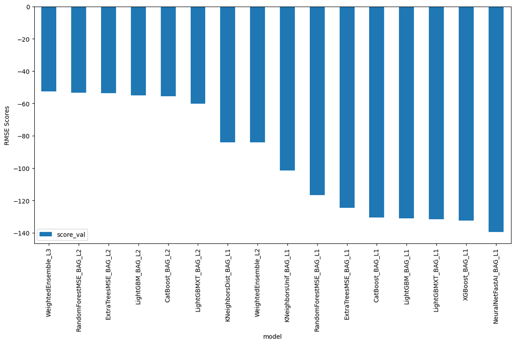

```python
import matplotlib.pyplot as plt
leaderboard_df.plot(kind="bar", x="model", y="score_val", figsize=(14, 7))
plt.ylabel("RMSE Scores")
plt.show()
```

### Create predictions from test dataset

```python
predictions = predictor.predict(test)
predictions.head()
```

```
0    23.094334
1    41.987740
2    46.182400
3    48.389175
4    51.470631
Name: count, dtype: float32
```

#### NOTE: Kaggle will reject the submission if we don't set everything to be > 0.

```python
# Describe the `predictions` series to see if there are any negative values
predictions.describe()
```

```
count    6493.000000
mean      100.816734
std        90.175980
min         3.020257
25%        21.211460
50%        62.573227
75%       171.437546
max       363.521210
Name: count, dtype: float64
```

```python
# How many negative values do we have?
negative_pred_count = predictions.apply(lambda x: 1 if x<0 else 0)

pred_pos_count = (negative_pred_count==0).sum()
pred_neg_count = (negative_pred_count==1).sum()

print("Total predictions                :", len(predictions.index))
print("Total positive prediction values :", pred_pos_count)
print("Total negative prediction values :", pred_neg_count)
```

```
Total predictions                : 6493
Total positive prediction values : 6493
Total negative prediction values : 0
```

```python
# Set them to zero
predictions[predictions<0] = 0
negative_pred_count = predictions.apply(lambda x: 1 if x<0 else 0)
pred_neg_count = (negative_pred_count==1).sum()
print(f"No. of negative predictions: {pred_neg_count}")
print("All negative values in the predictions (if any) are set to zero successfully.")
```

```
No. of negative predictions: 0
All negative values in the predictions (if any) are set to zero successfully.
```

### Set predictions to submission dataframe, save, and submit

```python
submission["count"] = predictions
submission.to_csv("submission.csv", index=False)
```

```python
pip install kaggle
```

```python
!kaggle competitions submit -c bike-sharing-demand -f submission.csv -m "first raw submission"
```

```
Successfully submitted to Bike Sharing Demand
```

#### View submission via the command line or in the web browser under the competition's page - `My Submissions`

```python
!kaggle competitions submissions -c bike-sharing-demand | tail -n +1 | head -n 6
```

```
fileName                     date                 description                          status    publicScore  privateScore
---------------------------  -------------------  -----------------------------------  --------  -----------  ------------
submission.csv               2024-05-09 21:48:21  first raw submission                 complete  1.80127      1.80127
submission.csv               2024-05-09 21:25:26  first raw submission                 complete  1.80538      1.80538
submission_new_hpo2.csv      2024-05-09 18:39:59  new features with hyperparameters 2  complete  0.50836      0.50836
submission_new_hpo1.csv      2024-05-09 18:33:30  new features with hyperparameters 1  complete  0.50829      0.50829
```

#### Initial score of 1.80127

## Step 4: Exploratory Data Analysis and Creating an additional feature

- Any additional feature will do, but a great suggestion would be to separate out the datetime into hour, day, or month parts.

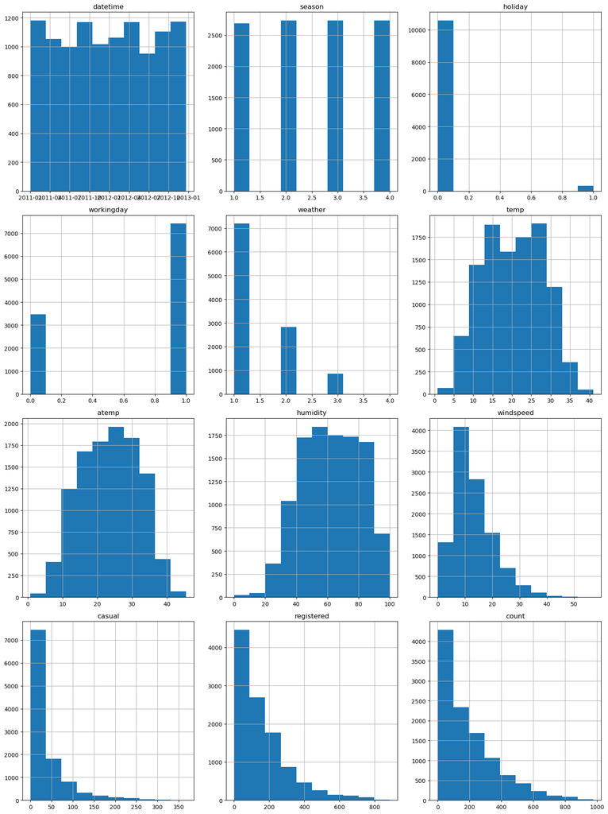

```python
# Create a histogram of all features to show the distribution of each one relative to the data. This is part of the exploritory data analysis
train.hist(figsize=(15,20))
plt.tight_layout()
plt.show()
```

```python
pip install seaborn
```

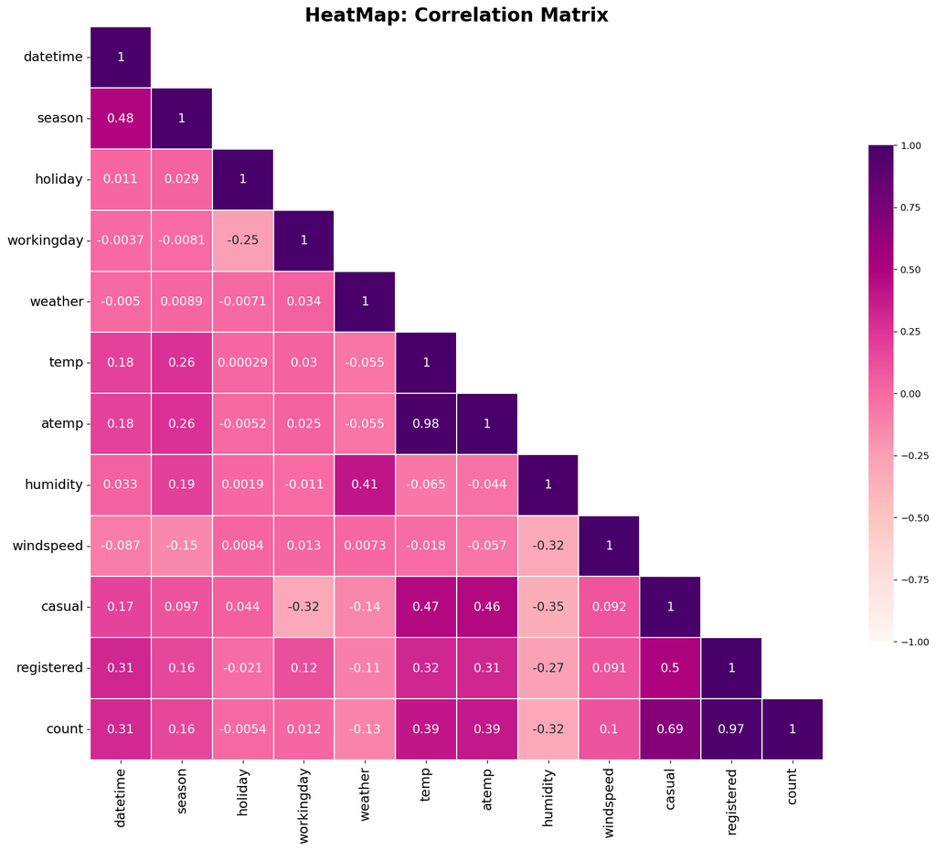

```python
#Plotting heatmap
import numpy as np
import matplotlib.pyplot as plt
import seaborn as sns
plt.figure(figsize = (15,15), dpi=120)
corr_data = train.copy()

corr_matrix = corr_data.corr()
f, ax_corr1 = plt.subplots(figsize=(15, 15), dpi=120)
corr_mask = np.array(corr_matrix)
corr_mask[np.tril_indices_from(corr_mask)] = False

ax_corr1 = sns.heatmap(corr_matrix, cmap= 'RdPu', cbar_kws={"shrink": .5}, vmin= -1, vmax=1, center=0,
            square=True, mask=corr_mask, annot=True, linewidths=0.01, annot_kws={"size":13})
plt.xticks(fontsize=14, rotation=90)
plt.yticks(fontsize=14, rotation=0)
plt.title("HeatMap: Correlation Matrix", fontsize=20, fontweight='bold')
plt.tight_layout()
plt.autoscale()
plt.show()
```

```python
# create a new feature
train['datetime'].head()
```

```
0   2011-01-01 00:00:00
1   2011-01-01 01:00:00
2   2011-01-01 02:00:00
3   2011-01-01 03:00:00
4   2011-01-01 04:00:00
Name: datetime, dtype: datetime64[ns]
```

```python
train["year"] = train["datetime"].dt.year
train["month"] = train["datetime"].dt.month
train["day"] = train["datetime"].dt.dayofweek
train["hour"] = train["datetime"].dt.hour
train.drop(["datetime"], axis=1, inplace=True)
train.head()
```

|  | season | holiday | workingday | weather | temp | atemp | humidity | windspeed | casual | registered | count | year | month | day | hour |
| --- | --- | --- | --- | --- | --- | --- | --- | --- | --- | --- | --- | --- | --- | --- | --- |
| 0 | 1 | 0 | 0 | 1 | 9.84 | 14.395 | 81 | 0.0 | 3 | 13 | 16 | 2011 | 1 | 5 | 0 |
| 1 | 1 | 0 | 0 | 1 | 9.02 | 13.635 | 80 | 0.0 | 8 | 32 | 40 | 2011 | 1 | 5 | 1 |
| 2 | 1 | 0 | 0 | 1 | 9.02 | 13.635 | 80 | 0.0 | 5 | 27 | 32 | 2011 | 1 | 5 | 2 |
| 3 | 1 | 0 | 0 | 1 | 9.84 | 14.395 | 75 | 0.0 | 3 | 10 | 13 | 2011 | 1 | 5 | 3 |
| 4 | 1 | 0 | 0 | 1 | 9.84 | 14.395 | 75 | 0.0 | 0 | 1 | 1 | 2011 | 1 | 5 | 4 |

```python
test["year"] = test["datetime"].dt.year
test["month"] = test["datetime"].dt.month
test["day"] = test["datetime"].dt.dayofweek  # Note: day -> dayofweek (0->Monday, 6->Sunday)
test["hour"] = test["datetime"].dt.hour
test.drop(["datetime"], axis=1, inplace=True)   # Drop 'datetime' feature
test.head()
```

|  | season | holiday | workingday | weather | temp | atemp | humidity | windspeed | year | month | day | hour |
| --- | --- | --- | --- | --- | --- | --- | --- | --- | --- | --- | --- | --- |
| 0 | 1 | 0 | 1 | 1 | 10.66 | 11.365 | 56 | 26.0027 | 2011 | 1 | 3 | 0 |
| 1 | 1 | 0 | 1 | 1 | 10.66 | 13.635 | 56 | 0.0000 | 2011 | 1 | 3 | 1 |
| 2 | 1 | 0 | 1 | 1 | 10.66 | 13.635 | 56 | 0.0000 | 2011 | 1 | 3 | 2 |
| 3 | 1 | 0 | 1 | 1 | 10.66 | 12.880 | 56 | 11.0014 | 2011 | 1 | 3 | 3 |
| 4 | 1 | 0 | 1 | 1 | 10.66 | 12.880 | 56 | 11.0014 | 2011 | 1 | 3 | 4 |

## Make category types for these so models know they are not just numbers

- AutoGluon originally sees these as ints, but in reality they are int representations of a category.
- Setting the dtype to category will classify these as categories in AutoGluon.

```python
train.info()
```

```
<class 'pandas.core.frame.DataFrame'>
RangeIndex: 10886 entries, 0 to 10885
Data columns (total 15 columns):
 #   Column      Non-Null Count  Dtype
---  ------      --------------  -----
 0   season      10886 non-null  int64
 1   holiday     10886 non-null  int64
 2   workingday  10886 non-null  int64
 3   weather     10886 non-null  int64
 4   temp        10886 non-null  float64
 5   atemp       10886 non-null  float64
 6   humidity    10886 non-null  int64
 7   windspeed   10886 non-null  float64
 8   casual      10886 non-null  int64
 9   registered  10886 non-null  int64
 10  count       10886 non-null  int64
 11  year        10886 non-null  int32
 12  month       10886 non-null  int32
 13  day         10886 non-null  int32
 14  hour        10886 non-null  int32
dtypes: float64(3), int32(4), int64(8)
memory usage: 1.1 MB
```

```python
train["season"] = train["season"].astype("category")
train["weather"] = train["weather"].astype("category")
test["season"] = test["season"].astype("category")
test["weather"] = test["weather"].astype("category")
```

```python
# View are new feature
train.head()
```

|  | season | holiday | workingday | weather | temp | atemp | humidity | windspeed | casual | registered | count | year | month | day | hour |
| --- | --- | --- | --- | --- | --- | --- | --- | --- | --- | --- | --- | --- | --- | --- | --- |
| 0 | 1 | 0 | 0 | 1 | 9.84 | 14.395 | 81 | 0.0 | 3 | 13 | 16 | 2011 | 1 | 5 | 0 |
| 1 | 1 | 0 | 0 | 1 | 9.02 | 13.635 | 80 | 0.0 | 8 | 32 | 40 | 2011 | 1 | 5 | 1 |
| 2 | 1 | 0 | 0 | 1 | 9.02 | 13.635 | 80 | 0.0 | 5 | 27 | 32 | 2011 | 1 | 5 | 2 |
| 3 | 1 | 0 | 0 | 1 | 9.84 | 14.395 | 75 | 0.0 | 3 | 10 | 13 | 2011 | 1 | 5 | 3 |
| 4 | 1 | 0 | 0 | 1 | 9.84 | 14.395 | 75 | 0.0 | 0 | 1 | 1 | 2011 | 1 | 5 | 4 |

```python
train.info()
```

```
<class 'pandas.core.frame.DataFrame'>
RangeIndex: 10886 entries, 0 to 10885
Data columns (total 15 columns):
 #   Column      Non-Null Count  Dtype
---  ------      --------------  -----
 0   season      10886 non-null  category
 1   holiday     10886 non-null  int64
 2   workingday  10886 non-null  int64
 3   weather     10886 non-null  category
 4   temp        10886 non-null  float64
 5   atemp       10886 non-null  float64
 6   humidity    10886 non-null  int64
 7   windspeed   10886 non-null  float64
 8   casual      10886 non-null  int64
 9   registered  10886 non-null  int64
 10  count       10886 non-null  int64
 11  year        10886 non-null  int32
 12  month       10886 non-null  int32
 13  day         10886 non-null  int32
 14  hour        10886 non-null  int32
dtypes: category(2), float64(3), int32(4), int64(6)
memory usage: 957.3 KB
```

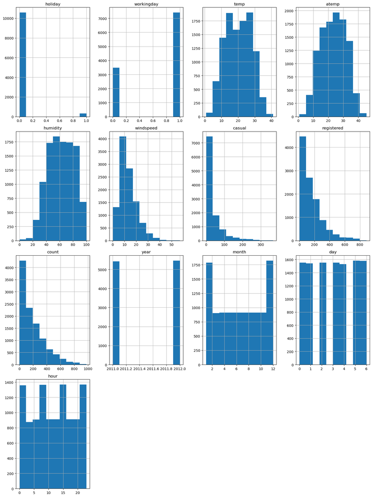

```python
# View histogram of all features again now with the hour feature
train.hist(figsize=(15,20))

plt.tight_layout()
plt.show()
```

## Step 5: Rerun the model with the same settings as before, just with more features

```python
eval_metric = 'root_mean_squared_error'
label = 'count'
ignored_columns = ["casual", "registered"]   # Ignored columns while training
train_data = train                           # 'casual' and 'registered' columns are already dropped/ignored
time_limit = 600                             # 10 minutes -> 60*10 = 600 seconds
presets = "best_quality"
```

```python
predictor_new_features = TabularPredictor(label=label,
                                          problem_type= 'regression',
                                          eval_metric=eval_metric,
                                          learner_kwargs={'ignored_columns': ignored_columns}).fit(
                                                                                           train_data = train_data,
                                                                                           time_limit=time_limit,
                                                                                           presets=presets)
```

```
No path specified. Models will be saved in: "AutogluonModels/ag-20240509_214840"
Presets specified: ['best_quality']
Stack configuration (auto_stack=True): num_stack_levels=1, num_bag_folds=8, num_bag_sets=20
Beginning AutoGluon training ... Time limit = 600s
AutoGluon will save models to "AutogluonModels/ag-20240509_214840"
AutoGluon Version:  0.8.2
Python Version:     3.10.14
Operating System:   Linux
Platform Machine:   x86_64
Platform Version:   #1 SMP Sat Mar 23 09:49:55 UTC 2024
Disk Space Avail:   89.81 GB / 106.29 GB (84.5%)
Train Data Rows:    10886
Train Data Columns: 14
Label Column: count
Preprocessing data ...
Using Feature Generators to preprocess the data ...
Dropping user-specified ignored columns: ['casual', 'registered']
Fitting AutoMLPipelineFeatureGenerator...
	Available Memory:                    2252.36 MB
	Train Data (Original)  Memory Usage: 0.72 MB (0.0% of available memory)
	Inferring data type of each feature based on column values. Set feature_metadata_in to manually specify special dtypes of the features.
	Stage 1 Generators:
		Fitting AsTypeFeatureGenerator...
			Note: Converting 3 features to boolean dtype as they only contain 2 unique values.
	Stage 2 Generators:
		Fitting FillNaFeatureGenerator...
	Stage 3 Generators:
		Fitting IdentityFeatureGenerator...
		Fitting CategoryFeatureGenerator...
			Fitting CategoryMemoryMinimizeFeatureGenerator...
	Stage 4 Generators:
		Fitting DropUniqueFeatureGenerator...
	Stage 5 Generators:
		Fitting DropDuplicatesFeatureGenerator...
	Types of features in original data (raw dtype, special dtypes):
		('category', []) : 2 | ['season', 'weather']
		('float', [])    : 3 | ['temp', 'atemp', 'windspeed']
		('int', [])      : 7 | ['holiday', 'workingday', 'humidity', 'year', 'month', ...]
	Types of features in processed data (raw dtype, special dtypes):
		('category', [])  : 2 | ['season', 'weather']
```

[output cut: 18 more lines]

```
	'XT': [{'criterion': 'gini', 'ag_args': {'name_suffix': 'Gini', 'problem_types': ['binary', 'multiclass']}}, {'criterion': 'entropy', 'ag_args': {'name_suffix': 'Entr', 'problem_types': ['binary', 'multiclass']}}, {'criterion': 'squared_error', 'ag_args': {'name_suffix': 'MSE', 'problem_types': ['r…
	'KNN': [{'weights': 'uniform', 'ag_args': {'name_suffix': 'Unif'}}, {'weights': 'distance', 'ag_args': {'name_suffix': 'Dist'}}],
}
AutoGluon will fit 2 stack levels (L1 to L2) ...
Fitting 11 L1 models ...
Fitting model: KNeighborsUnif_BAG_L1 ... Training model for up to 399.81s of the 599.87s of remaining time.
	-115.7332	 = Validation score   (-root_mean_squared_error)
	0.03s	 = Training   runtime
	0.16s	 = Validation runtime
Fitting model: KNeighborsDist_BAG_L1 ... Training model for up to 399.6s of the 599.65s of remaining time.
	-112.1571	 = Validation score   (-root_mean_squared_error)
	0.03s	 = Training   runtime
	0.15s	 = Validation runtime
Fitting model: LightGBMXT_BAG_L1 ... Training model for up to 399.39s of the 599.44s of remaining time.
	Fitting 8 child models (S1F1 - S1F8) | Fitting with SequentialLocalFoldFittingStrategy
```

[output not shown]

```
	-36.4599	 = Validation score   (-root_mean_squared_error)
	64.54s	 = Training   runtime
	11.85s	 = Validation runtime
Fitting model: LightGBM_BAG_L1 ... Training model for up to 313.06s of the 513.11s of remaining time.
	Fitting 8 child models (S1F1 - S1F8) | Fitting with SequentialLocalFoldFittingStrategy
```

```
[1000]	valid_set's rmse: 35.0742
[1000]	valid_set's rmse: 34.1338
[2000]	valid_set's rmse: 33.9294
[1000]	valid_set's rmse: 34.257
[2000]	valid_set's rmse: 33.6373
[3000]	valid_set's rmse: 33.4395
[4000]	valid_set's rmse: 33.4325
[1000]	valid_set's rmse: 37.3575
[2000]	valid_set's rmse: 37.1945
[1000]	valid_set's rmse: 38.1734
[2000]	valid_set's rmse: 37.9207
[1000]	valid_set's rmse: 33.4459
[2000]	valid_set's rmse: 33.2585
[1000]	valid_set's rmse: 39.4999
[1000]	valid_set's rmse: 36.2444
```

```
	-35.7969	 = Validation score   (-root_mean_squared_error)
	18.56s	 = Training   runtime
	2.24s	 = Validation runtime
Fitting model: RandomForestMSE_BAG_L1 ... Training model for up to 289.6s of the 489.66s of remaining time.
	-39.5874	 = Validation score   (-root_mean_squared_error)
	14.1s	 = Training   runtime
	0.71s	 = Validation runtime
Fitting model: CatBoost_BAG_L1 ... Training model for up to 274.27s of the 474.33s of remaining time.
	Fitting 8 child models (S1F1 - S1F8) | Fitting with SequentialLocalFoldFittingStrategy
	Ran out of time, early stopping on iteration 2743.
	Ran out of time, early stopping on iteration 2650.
	Ran out of time, early stopping on iteration 2643.
	Ran out of time, early stopping on iteration 3371.
	Ran out of time, early stopping on iteration 2918.
	Ran out of time, early stopping on iteration 3192.
	Ran out of time, early stopping on iteration 3097.
	Ran out of time, early stopping on iteration 4286.
	-35.74	 = Validation score   (-root_mean_squared_error)
	263.04s	 = Training   runtime
	0.13s	 = Validation runtime
Fitting model: ExtraTreesMSE_BAG_L1 ... Training model for up to 10.98s of the 211.03s of remaining time.
	-39.0334	 = Validation score   (-root_mean_squared_error)
	7.81s	 = Training   runtime
	0.57s	 = Validation runtime
Fitting model: NeuralNetFastAI_BAG_L1 ... Training model for up to 2.16s of the 202.22s of remaining time.
	Fitting 8 child models (S1F1 - S1F8) | Fitting with SequentialLocalFoldFittingStrategy
	Time limit exceeded... Skipping NeuralNetFastAI_BAG_L1.
Fitting model: XGBoost_BAG_L1 ... Training model for up to 1.81s of the 201.86s of remaining time.
	Fitting 8 child models (S1F1 - S1F8) | Fitting with SequentialLocalFoldFittingStrategy
	-42.3705	 = Validation score   (-root_mean_squared_error)
	1.63s	 = Training   runtime
	0.11s	 = Validation runtime
Fitting model: NeuralNetTorch_BAG_L1 ... Training model for up to 0.01s of the 200.06s of remaining time.
	Fitting 8 child models (S1F1 - S1F8) | Fitting with SequentialLocalFoldFittingStrategy
	Time limit exceeded... Skipping NeuralNetTorch_BAG_L1.
Completed 1/20 k-fold bagging repeats ...
Fitting model: WeightedEnsemble_L2 ... Training model for up to 360.0s of the 200.04s of remaining time.
	-34.1412	 = Validation score   (-root_mean_squared_error)
	0.34s	 = Training   runtime
	0.0s	 = Validation runtime
```

[output cut: 32 more lines]

```
	-35.0418	 = Validation score   (-root_mean_squared_error)
	29.45s	 = Training   runtime
	0.28s	 = Validation runtime
Fitting model: XGBoost_BAG_L2 ... Training model for up to 1.6s of the 1.59s of remaining time.
	Fitting 8 child models (S1F1 - S1F8) | Fitting with SequentialLocalFoldFittingStrategy
	-90.7982	 = Validation score   (-root_mean_squared_error)
	1.56s	 = Training   runtime
	0.08s	 = Validation runtime
Completed 1/20 k-fold bagging repeats ...
Fitting model: WeightedEnsemble_L3 ... Training model for up to 360.0s of the -0.1s of remaining time.
	-33.9512	 = Validation score   (-root_mean_squared_error)
	0.36s	 = Training   runtime
	0.0s	 = Validation runtime
AutoGluon training complete, total runtime = 600.48s ... Best model: "WeightedEnsemble_L3"
TabularPredictor saved. To load, use: predictor = TabularPredictor.load("AutogluonModels/ag-20240509_214840")
```

```python
predictor_new_features.fit_summary()
```

```
*** Summary of fit() ***
Estimated performance of each model:
                     model   score_val  pred_time_val    fit_time  pred_time_val_marginal  fit_time_marginal  stack_level  can_infer  fit_order
0      WeightedEnsemble_L3  -33.951163      17.159981  514.924933                0.000611           0.361398            3       True         17
1      WeightedEnsemble_L2  -34.141234      15.500252  368.393310                0.000824           0.337739            2       True          9
2     ExtraTreesMSE_BAG_L2  -34.164025      16.727860  383.934137                0.810914          14.193890            2       True         14
3          CatBoost_BAG_L2  -34.381626      15.968569  463.765772                0.051622          94.025525            2       True         13
4          LightGBM_BAG_L2  -34.506634      16.013093  376.894814                0.096146           7.154567            2       True         11
5   RandomForestMSE_BAG_L2  -34.761839      16.588463  410.992397                0.671516          41.252150            2       True         12
6   NeuralNetFastAI_BAG_L2  -35.041849      16.200688  399.189553                0.283741          29.449306            2       True         15
7        LightGBMXT_BAG_L2  -35.123268      16.175925  377.915811                0.258978           8.175564            2       True         10
8          CatBoost_BAG_L1  -35.740009       0.133159  263.041650                0.133159         263.041650            1       True          6
9          LightGBM_BAG_L1  -35.796869       2.244120   18.562805                2.244120          18.562805            1       True          4
10       LightGBMXT_BAG_L1  -36.459884      11.845187   64.540663               11.845187          64.540663            1       True          3
11    ExtraTreesMSE_BAG_L1  -39.033394       0.571626    7.808860                0.571626           7.808860            1       True          7
12  RandomForestMSE_BAG_L1  -39.587441       0.705335   14.101592                0.705335          14.101592            1       True          5
13          XGBoost_BAG_L1  -42.370508       0.113137    1.629957                0.113137           1.629957            1       True          8
14          XGBoost_BAG_L2  -90.798225      15.995772  371.298569                0.078825           1.558322            2       True         16
15   KNeighborsDist_BAG_L1 -112.157112       0.148158    0.026646                0.148158           0.026646            1       True          2
16   KNeighborsUnif_BAG_L1 -115.733231       0.156225    0.028074                0.156225           0.028074            1       True          1
Number of models trained: 17
Types of models trained:
{'StackerEnsembleModel_LGB', 'StackerEnsembleModel_XGBoost', 'StackerEnsembleModel_CatBoost', 'StackerEnsembleModel_RF', 'StackerEnsembleModel_NNFastAiTabular', 'StackerEnsembleModel_XT', 'StackerEnsembleModel_KNN', 'WeightedEnsembleModel'}
Bagging used: True  (with 8 folds)
Multi-layer stack-ensembling used: True  (with 3 levels)
Feature Metadata (Processed):
(raw dtype, special dtypes):
('category', [])  : 2 | ['season', 'weather']
('float', [])     : 3 | ['temp', 'atemp', 'windspeed']
('int', [])       : 4 | ['humidity', 'month', 'day', 'hour']
('int', ['bool']) : 3 | ['holiday', 'workingday', 'year']
*** End of fit() summary ***
```

```
{'model_types': {'KNeighborsUnif_BAG_L1': 'StackerEnsembleModel_KNN',
  'KNeighborsDist_BAG_L1': 'StackerEnsembleModel_KNN',
  'LightGBMXT_BAG_L1': 'StackerEnsembleModel_LGB',
  'LightGBM_BAG_L1': 'StackerEnsembleModel_LGB',
  'RandomForestMSE_BAG_L1': 'StackerEnsembleModel_RF',
  'CatBoost_BAG_L1': 'StackerEnsembleModel_CatBoost',
  'ExtraTreesMSE_BAG_L1': 'StackerEnsembleModel_XT',
  'XGBoost_BAG_L1': 'StackerEnsembleModel_XGBoost',
  'WeightedEnsemble_L2': 'WeightedEnsembleModel',
  'LightGBMXT_BAG_L2': 'StackerEnsembleModel_LGB',
  'LightGBM_BAG_L2': 'StackerEnsembleModel_LGB',
  'RandomForestMSE_BAG_L2': 'StackerEnsembleModel_RF',
  'CatBoost_BAG_L2': 'StackerEnsembleModel_CatBoost',
  'ExtraTreesMSE_BAG_L2': 'StackerEnsembleModel_XT',
  'NeuralNetFastAI_BAG_L2': 'StackerEnsembleModel_NNFastAiTabular',
  'XGBoost_BAG_L2': 'StackerEnsembleModel_XGBoost',
  'WeightedEnsemble_L3': 'WeightedEnsembleModel'},
 'model_performance': {'KNeighborsUnif_BAG_L1': -115.73323148534313,
  'KNeighborsDist_BAG_L1': -112.15711242835349,
  'LightGBMXT_BAG_L1': -36.45988391821316,
  'LightGBM_BAG_L1': -35.79686905713535,
  'RandomForestMSE_BAG_L1': -39.587440921643605,
  'CatBoost_BAG_L1': -35.740008916188394,
  'ExtraTreesMSE_BAG_L1': -39.03339387756181,
  'XGBoost_BAG_L1': -42.3705078628296,
  'WeightedEnsemble_L2': -34.14123365443084,
  'LightGBMXT_BAG_L2': -35.12326770606826,
  'LightGBM_BAG_L2': -34.50663448991975,
  'RandomForestMSE_BAG_L2': -34.7618389912639,
  'CatBoost_BAG_L2': -34.38162592731349,
  'ExtraTreesMSE_BAG_L2': -34.164024984718274,
  'NeuralNetFastAI_BAG_L2': -35.04184911313198,
  'XGBoost_BAG_L2': -90.79822548090746,
  'WeightedEnsemble_L3': -33.95116296128793},
 'model_best': 'WeightedEnsemble_L3',
 'model_paths': {'KNeighborsUnif_BAG_L1': ['KNeighborsUnif_BAG_L1'],
  'KNeighborsDist_BAG_L1': ['KNeighborsDist_BAG_L1'],
  'LightGBMXT_BAG_L1': ['LightGBMXT_BAG_L1'],
  'LightGBM_BAG_L1': ['LightGBM_BAG_L1'],
  'RandomForestMSE_BAG_L1': ['RandomForestMSE_BAG_L1'],
```

[output cut: 163 more lines]

```
 2          14
 3          13
 4          11
 5          12
 6          15
 7          10
 8           6
 9           4
 10          3
 11          7
 12          5
 13          8
 14         16
 15          2
 16          1  }
```

```python
leaderboard_new_features_df = pd.DataFrame(predictor_new_features.leaderboard(silent=True))
leaderboard_new_features_df
```

|  | model | score_val | pred_time_val | fit_time | pred_time_val_marginal | fit_time_marginal | stack_level | can_infer | fit_order |
| --- | --- | --- | --- | --- | --- | --- | --- | --- | --- |
| 0 | WeightedEnsemble_L3 | -33.951163 | 17.159981 | 514.924933 | 0.000611 | 0.361398 | 3 | True | 17 |
| 1 | WeightedEnsemble_L2 | -34.141234 | 15.500252 | 368.393310 | 0.000824 | 0.337739 | 2 | True | 9 |
| 2 | ExtraTreesMSE_BAG_L2 | -34.164025 | 16.727860 | 383.934137 | 0.810914 | 14.193890 | 2 | True | 14 |
| 3 | CatBoost_BAG_L2 | -34.381626 | 15.968569 | 463.765772 | 0.051622 | 94.025525 | 2 | True | 13 |
| 4 | LightGBM_BAG_L2 | -34.506634 | 16.013093 | 376.894814 | 0.096146 | 7.154567 | 2 | True | 11 |
| 5 | RandomForestMSE_BAG_L2 | -34.761839 | 16.588463 | 410.992397 | 0.671516 | 41.252150 | 2 | True | 12 |
| 6 | NeuralNetFastAI_BAG_L2 | -35.041849 | 16.200688 | 399.189553 | 0.283741 | 29.449306 | 2 | True | 15 |
| 7 | LightGBMXT_BAG_L2 | -35.123268 | 16.175925 | 377.915811 | 0.258978 | 8.175564 | 2 | True | 10 |
| 8 | CatBoost_BAG_L1 | -35.740009 | 0.133159 | 263.041650 | 0.133159 | 263.041650 | 1 | True | 6 |
| 9 | LightGBM_BAG_L1 | -35.796869 | 2.244120 | 18.562805 | 2.244120 | 18.562805 | 1 | True | 4 |
| 10 | LightGBMXT_BAG_L1 | -36.459884 | 11.845187 | 64.540663 | 11.845187 | 64.540663 | 1 | True | 3 |
| 11 | ExtraTreesMSE_BAG_L1 | -39.033394 | 0.571626 | 7.808860 | 0.571626 | 7.808860 | 1 | True | 7 |
| 12 | RandomForestMSE_BAG_L1 | -39.587441 | 0.705335 | 14.101592 | 0.705335 | 14.101592 | 1 | True | 5 |
| 13 | XGBoost_BAG_L1 | -42.370508 | 0.113137 | 1.629957 | 0.113137 | 1.629957 | 1 | True | 8 |
| 14 | XGBoost_BAG_L2 | -90.798225 | 15.995772 | 371.298569 | 0.078825 | 1.558322 | 2 | True | 16 |
| 15 | KNeighborsDist_BAG_L1 | -112.157112 | 0.148158 | 0.026646 | 0.148158 | 0.026646 | 1 | True | 2 |
| 16 | KNeighborsUnif_BAG_L1 | -115.733231 | 0.156225 | 0.028074 | 0.156225 | 0.028074 | 1 | True | 1 |

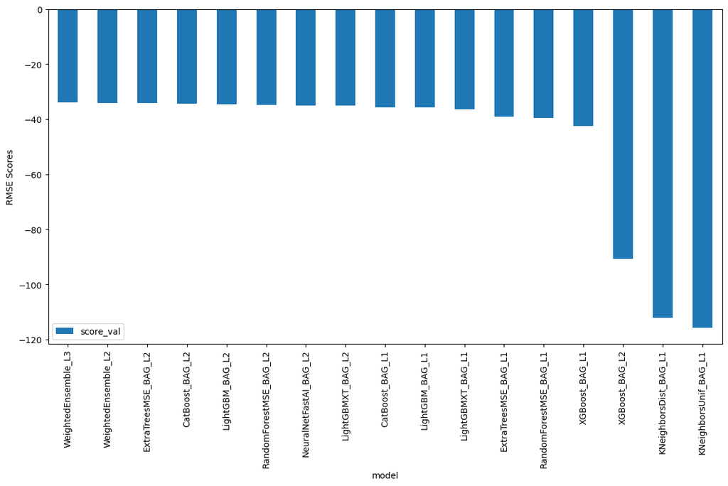

```python
import matplotlib.pyplot as plt
leaderboard_new_features_df.plot(kind="bar", x="model", y="score_val", figsize=(14, 7))
plt.ylabel("RMSE Scores")
plt.show()
```

```python
predictions_new_features = predictor_new_features.predict(test)
predictions_new_features.head()
```

```
0    12.619491
1     6.069458
2     4.096957
3     4.060750
4     3.931960
Name: count, dtype: float32
```

```python
# Explaining the predictions_new_features dataset to check for the presence of any negative values.
predictions_new_features.describe()
```

```
count    6493.000000
mean      189.947189
std       174.455750
min         1.998520
25%        45.210587
50%       146.778015
75%       281.002563
max       907.261414
Name: count, dtype: float64
```

```python
negative = predictions_new_features.apply(lambda x: 1 if x<0 else 0)

pred_count = (negative==0).sum()
predneg_count = (negative==1).sum()

print("Total predictions                :", len(predictions_new_features.index))
print("Total positive prediction values :", pred_count)
print("Total negative prediction values :", predneg_count)
```

```
Total predictions                : 6493
Total positive prediction values : 6493
Total negative prediction values : 0
```

```python
# Remember to set all negative values to zero
predictions_new_features[predictions_new_features<0] = 0

# Rechecking, if no predictions are less than 0
negative = predictions_new_features.apply(lambda x: 1 if x<0 else 0)
pred_neg_count = (negative==1).sum()
print(f"No. of negative predictions: {predneg_count}")
print("All negative values in the predictions (if there are any) are set to zero successfully.")
```

```
No. of negative predictions: 0
All negative values in the predictions (if there are any) are set to zero successfully.
```

```python
# Same submitting predictions
submission_new_features = pd.read_csv('sampleSubmission.csv', parse_dates = ['datetime'])
submission_new_features.head()
```

|  | datetime | count |
| --- | --- | --- |
| 0 | 2011-01-20 00:00:00 | 0 |
| 1 | 2011-01-20 01:00:00 | 0 |
| 2 | 2011-01-20 02:00:00 | 0 |
| 3 | 2011-01-20 03:00:00 | 0 |
| 4 | 2011-01-20 04:00:00 | 0 |

```python
submission_new_features["count"] = predictions_new_features
submission_new_features.to_csv("submission_new_features.csv", index=False)
```

```python
!kaggle competitions submit -c bike-sharing-demand -f submission_new_features.csv -m "new features"
```

```
Successfully submitted to Bike Sharing Demand
```

```python
!kaggle competitions submissions -c bike-sharing-demand | tail -n +1 | head -n 6
```

```
fileName                     date                 description                          status    publicScore  privateScore
---------------------------  -------------------  -----------------------------------  --------  -----------  ------------
submission_new_features.csv  2024-05-09 22:00:02  new features                         complete  0.45087      0.45087
submission.csv               2024-05-09 21:48:21  first raw submission                 complete  1.80127      1.80127
submission.csv               2024-05-09 21:25:26  first raw submission                 complete  1.80538      1.80538
submission_new_hpo2.csv      2024-05-09 18:39:59  new features with hyperparameters 2  complete  0.50836      0.50836
```

#### New Score of 0.45087

## Step 6: Hyper parameter optimization

- There are many options for hyper parameter optimization.
- Options are to change the AutoGluon higher level parameters or the individual model hyperparameters.
- The hyperparameters of the models themselves that are in AutoGluon. Those need the `hyperparameter` and `hyperparameter_tune_kwargs` arguments.

```python
eval_metric = 'root_mean_squared_error'
label = 'count'
ignored_columns = ["casual", "registered"]
train_data = train
time_limit = 600
presets = "optimize_for_deployment"
```

```python
import autogluon.core as ag
## From autogluon documentation

nn_options = {'num_epochs': 5,
              'learning_rate': ag.space.Real(1e-4, 1e-2, default=5e-4, log=True),
                    # learning rate used in training (real-valued hyperparameter searched on log-scale)
              'activation': ag.space.Categorical('relu', 'softrelu', 'tanh'),
                    # activation function used in NN (categorical hyperparameter, default = first entry)
              'dropout_prob': ag.space.Real(0.0, 0.5, default=0.1)}

gbm_options = [{'extra_trees': True,
                'num_boost_round': ag.space.Int(lower=100, upper=500, default=100),
                'num_leaves': ag.space.Int(lower=25, upper=64, default=36),
                'ag_args': {'name_suffix': 'XT'}}, {}, 'GBMLarge']

hyperparameters = {  # hyperparameters of each model type
                   'GBM': gbm_options,
                   'NN_TORCH': nn_options,
                  }

num_trials = 20            # Number of hyperparameter optimization trials you want to perform
search_strategy = 'auto'  # tune hyperparameters using Bayesian optimization routine with a local scheduler
scheduler = 'local'       # Local FIFO scheduler

hyperparameter_tune_kwargs = {
    'num_trials': num_trials,
    'scheduler' : scheduler,
    'searcher': search_strategy,
}

predictor_new_hpo = TabularPredictor(label='count', problem_type='regression', eval_metric='root_mean_squared_error',
                                    learner_kwargs={'ignored_columns': ignored_columns}).fit(
                                                                         train_data=train,
                                                                         time_limit=time_limit,
                                                                         presets=presets,
                                                                         hyperparameters=hyperparameters,
                                                                         hyperparameter_tune_kwargs=hyperparameter_tune_kwargs,
                                                                         refit_full='best')
```

```
No path specified. Models will be saved in: "AutogluonModels/ag-20240509_220005"
Presets specified: ['optimize_for_deployment']
Warning: hyperparameter tuning is currently experimental and may cause the process to hang.
Beginning AutoGluon training ... Time limit = 600s
AutoGluon will save models to "AutogluonModels/ag-20240509_220005"
AutoGluon Version:  0.8.2
Python Version:     3.10.14
Operating System:   Linux
Platform Machine:   x86_64
Platform Version:   #1 SMP Sat Mar 23 09:49:55 UTC 2024
Disk Space Avail:   88.48 GB / 106.29 GB (83.2%)
Train Data Rows:    10886
Train Data Columns: 14
Label Column: count
Preprocessing data ...
Using Feature Generators to preprocess the data ...
Dropping user-specified ignored columns: ['casual', 'registered']
Fitting AutoMLPipelineFeatureGenerator...
	Available Memory:                    2211.23 MB
	Train Data (Original)  Memory Usage: 0.72 MB (0.0% of available memory)
	Inferring data type of each feature based on column values. Set feature_metadata_in to manually specify special dtypes of the features.
	Stage 1 Generators:
		Fitting AsTypeFeatureGenerator...
			Note: Converting 3 features to boolean dtype as they only contain 2 unique values.
	Stage 2 Generators:
		Fitting FillNaFeatureGenerator...
	Stage 3 Generators:
		Fitting IdentityFeatureGenerator...
		Fitting CategoryFeatureGenerator...
			Fitting CategoryMemoryMinimizeFeatureGenerator...
	Stage 4 Generators:
		Fitting DropUniqueFeatureGenerator...
	Stage 5 Generators:
		Fitting DropDuplicatesFeatureGenerator...
	Types of features in original data (raw dtype, special dtypes):
		('category', []) : 2 | ['season', 'weather']
		('float', [])    : 3 | ['temp', 'atemp', 'windspeed']
		('int', [])      : 7 | ['holiday', 'workingday', 'humidity', 'year', 'month', ...]
	Types of features in processed data (raw dtype, special dtypes):
		('category', [])  : 2 | ['season', 'weather']
		('float', [])     : 3 | ['temp', 'atemp', 'windspeed']
		('int', [])       : 4 | ['humidity', 'month', 'day', 'hour']
		('int', ['bool']) : 3 | ['holiday', 'workingday', 'year']
	0.5s = Fit runtime
	12 features in original data used to generate 12 features in processed data.
	Train Data (Processed) Memory Usage: 0.53 MB (0.0% of available memory)
Data preprocessing and feature engineering runtime = 0.62s ...
AutoGluon will gauge predictive performance using evaluation metric: 'root_mean_squared_error'
	This metric's sign has been flipped to adhere to being higher_is_better. The metric score can be multiplied by -1 to get the metric value.
	To change this, specify the eval_metric parameter of Predictor()
Automatically generating train/validation split with holdout_frac=0.2, Train Rows: 8708, Val Rows: 2178
User-specified model hyperparameters to be fit:
{
	'GBM': [{'extra_trees': True, 'num_boost_round': Int: lower=100, upper=500, 'num_leaves': Int: lower=25, upper=64, 'ag_args': {'name_suffix': 'XT'}}, {}, 'GBMLarge'],
	'NN_TORCH': {'num_epochs': 5, 'learning_rate': Real: lower=0.0001, upper=0.01, 'activation': Categorical['relu', 'softrelu', 'tanh'], 'dropout_prob': Real: lower=0.0, upper=0.5},
}
Fitting 4 L1 models ...
Hyperparameter tuning model: LightGBMXT ... Tuning model for up to 134.86s of the 599.35s of remaining time.
```

```
Fitted model: LightGBMXT/T1 ...
	-77.0034	 = Validation score   (-root_mean_squared_error)
	1.11s	 = Training   runtime
	0.04s	 = Validation runtime
Fitted model: LightGBMXT/T2 ...
	-44.4103	 = Validation score   (-root_mean_squared_error)
	1.77s	 = Training   runtime
	0.29s	 = Validation runtime
Fitted model: LightGBMXT/T3 ...
	-47.005	 = Validation score   (-root_mean_squared_error)
	1.66s	 = Training   runtime
	0.13s	 = Validation runtime
Fitted model: LightGBMXT/T4 ...
	-42.6588	 = Validation score   (-root_mean_squared_error)
	0.99s	 = Training   runtime
	0.1s	 = Validation runtime
Fitted model: LightGBMXT/T5 ...
	-63.8359	 = Validation score   (-root_mean_squared_error)
	0.71s	 = Training   runtime
	0.07s	 = Validation runtime
Fitted model: LightGBMXT/T6 ...
	-107.9925	 = Validation score   (-root_mean_squared_error)
	0.74s	 = Training   runtime
	0.11s	 = Validation runtime
Fitted model: LightGBMXT/T7 ...
	-47.8059	 = Validation score   (-root_mean_squared_error)
	0.72s	 = Training   runtime
	0.07s	 = Validation runtime
Fitted model: LightGBMXT/T8 ...
	-48.4353	 = Validation score   (-root_mean_squared_error)
	1.56s	 = Training   runtime
	0.23s	 = Validation runtime
Fitted model: LightGBMXT/T9 ...
	-126.9032	 = Validation score   (-root_mean_squared_error)
	0.55s	 = Training   runtime
	0.04s	 = Validation runtime
Fitted model: LightGBMXT/T10 ...
	-74.5052	 = Validation score   (-root_mean_squared_error)
	1.54s	 = Training   runtime
	0.2s	 = Validation runtime
```

[output cut: 26 more lines]

```
	0.69s	 = Training   runtime
	0.1s	 = Validation runtime
Fitted model: LightGBMXT/T18 ...
	-63.7447	 = Validation score   (-root_mean_squared_error)
	0.84s	 = Training   runtime
	0.09s	 = Validation runtime
Fitted model: LightGBMXT/T19 ...
	-92.2047	 = Validation score   (-root_mean_squared_error)
	0.46s	 = Training   runtime
	0.04s	 = Validation runtime
Fitted model: LightGBMXT/T20 ...
	-44.6324	 = Validation score   (-root_mean_squared_error)
	0.84s	 = Training   runtime
	0.12s	 = Validation runtime
Hyperparameter tuning model: LightGBM ... Tuning model for up to 134.86s of the 576.31s of remaining time.
```

[output not shown]

```
	Stopping HPO to satisfy time limit...
Fitted model: LightGBM/T1 ...
	-38.4437	 = Validation score   (-root_mean_squared_error)
	3.39s	 = Training   runtime
	0.6s	 = Validation runtime
Fitted model: LightGBM/T2 ...
	-38.6737	 = Validation score   (-root_mean_squared_error)
	1.17s	 = Training   runtime
	0.07s	 = Validation runtime
Fitted model: LightGBM/T3 ...
	-39.0593	 = Validation score   (-root_mean_squared_error)
	2.94s	 = Training   runtime
	0.43s	 = Validation runtime
Fitted model: LightGBM/T4 ...
	-38.162	 = Validation score   (-root_mean_squared_error)
	13.48s	 = Training   runtime
	3.24s	 = Validation runtime
Fitted model: LightGBM/T5 ...
	-38.4992	 = Validation score   (-root_mean_squared_error)
	1.35s	 = Training   runtime
	0.19s	 = Validation runtime
Fitted model: LightGBM/T6 ...
	-38.3412	 = Validation score   (-root_mean_squared_error)
	5.7s	 = Training   runtime
	0.76s	 = Validation runtime
Fitted model: LightGBM/T7 ...
	-38.4489	 = Validation score   (-root_mean_squared_error)
	2.5s	 = Training   runtime
	0.19s	 = Validation runtime
Fitted model: LightGBM/T8 ...
	-39.3363	 = Validation score   (-root_mean_squared_error)
	1.67s	 = Training   runtime
	0.23s	 = Validation runtime
Fitted model: LightGBM/T9 ...
	-38.3005	 = Validation score   (-root_mean_squared_error)
	15.06s	 = Training   runtime
	4.14s	 = Validation runtime
Fitted model: LightGBM/T10 ...
	-38.9684	 = Validation score   (-root_mean_squared_error)
	1.42s	 = Training   runtime
```

[output cut: 8 more lines]

```
	1.03s	 = Validation runtime
Fitted model: LightGBM/T13 ...
	-38.4372	 = Validation score   (-root_mean_squared_error)
	7.44s	 = Training   runtime
	1.54s	 = Validation runtime
Fitted model: LightGBM/T14 ...
	-38.6473	 = Validation score   (-root_mean_squared_error)
	10.05s	 = Training   runtime
	2.3s	 = Validation runtime
Fitted model: LightGBM/T15 ...
	-39.1908	 = Validation score   (-root_mean_squared_error)
	11.77s	 = Training   runtime
	5.94s	 = Validation runtime
Hyperparameter tuning model: NeuralNetTorch ... Tuning model for up to 134.86s of the 446.68s of remaining time.
Will use custom hpo logic because ray import failed. Reason: ray==2.21.0 detected. 2.6.3 <= ray < 2.7.0 is required. You can use pip to install certain version of ray `pip install ray==2.6.3`
```

```
Fitted model: NeuralNetTorch/T1 ...
	-112.34	 = Validation score   (-root_mean_squared_error)
	2.6s	 = Training   runtime
	0.01s	 = Validation runtime
Fitted model: NeuralNetTorch/T2 ...
	-69.8113	 = Validation score   (-root_mean_squared_error)
	4.74s	 = Training   runtime
	0.03s	 = Validation runtime
Fitted model: NeuralNetTorch/T3 ...
	-87.6205	 = Validation score   (-root_mean_squared_error)
	3.6s	 = Training   runtime
	0.05s	 = Validation runtime
Fitted model: NeuralNetTorch/T4 ...
	-67.3898	 = Validation score   (-root_mean_squared_error)
	7.61s	 = Training   runtime
	0.04s	 = Validation runtime
Fitted model: NeuralNetTorch/T5 ...
	-139.9616	 = Validation score   (-root_mean_squared_error)
	11.29s	 = Training   runtime
	0.06s	 = Validation runtime
Fitted model: NeuralNetTorch/T6 ...
	-144.4419	 = Validation score   (-root_mean_squared_error)
	1.68s	 = Training   runtime
	0.02s	 = Validation runtime
Fitted model: NeuralNetTorch/T7 ...
	-144.1982	 = Validation score   (-root_mean_squared_error)
	3.37s	 = Training   runtime
	0.02s	 = Validation runtime
Fitted model: NeuralNetTorch/T8 ...
	-121.0313	 = Validation score   (-root_mean_squared_error)
	2.0s	 = Training   runtime
	0.04s	 = Validation runtime
Fitted model: NeuralNetTorch/T9 ...
	-144.8633	 = Validation score   (-root_mean_squared_error)
	4.88s	 = Training   runtime
	0.03s	 = Validation runtime
Fitted model: NeuralNetTorch/T10 ...
	-106.1286	 = Validation score   (-root_mean_squared_error)
	3.14s	 = Training   runtime
	0.02s	 = Validation runtime
```

[output cut: 26 more lines]

```
	1.97s	 = Training   runtime
	0.02s	 = Validation runtime
Fitted model: NeuralNetTorch/T18 ...
	-107.2537	 = Validation score   (-root_mean_squared_error)
	8.06s	 = Training   runtime
	0.04s	 = Validation runtime
Fitted model: NeuralNetTorch/T19 ...
	-142.575	 = Validation score   (-root_mean_squared_error)
	7.3s	 = Training   runtime
	0.07s	 = Validation runtime
Fitted model: NeuralNetTorch/T20 ...
	-147.1856	 = Validation score   (-root_mean_squared_error)
	4.21s	 = Training   runtime
	0.03s	 = Validation runtime
Fitting model: LightGBMLarge ... Training model for up to 134.86s of the 345.56s of remaining time.
```

```
[1000]	valid_set's rmse: 38.5198
```

[output not shown]

[output cut: 34 more lines]

[output not shown]

```python
predictor_new_hpo.fit_summary()
```

```
*** Summary of fit() ***
Estimated performance of each model:
                 model  score_val  pred_time_val   fit_time  pred_time_val_marginal  fit_time_marginal  stack_level  can_infer  fit_order
0  WeightedEnsemble_L2 -37.290631       2.914236  30.024292                0.000483           0.366736            2       True          6
1         LightGBM/T12 -38.007447       1.031841   6.965216                1.031841           6.965216            1       True          3
2         LightGBM/T11 -38.050854       1.040547   5.413697                1.040547           5.413697            1       True          2
3          LightGBM/T6 -38.341211       0.761645   5.700737                0.761645           5.700737            1       True          1
4    NeuralNetTorch/T2 -69.811257       0.026357   4.743390                0.026357           4.743390            1       True          4
5   NeuralNetTorch/T11 -73.959036       0.053363   6.834516                0.053363           6.834516            1       True          5
Number of models trained: 6
Types of models trained:
{'LGBModel', 'WeightedEnsembleModel', 'TabularNeuralNetTorchModel'}
Bagging used: False
Multi-layer stack-ensembling used: False
Feature Metadata (Processed):
(raw dtype, special dtypes):
('category', [])  : 2 | ['season', 'weather']
('float', [])     : 3 | ['temp', 'atemp', 'windspeed']
('int', [])       : 4 | ['humidity', 'month', 'day', 'hour']
('int', ['bool']) : 3 | ['holiday', 'workingday', 'year']
*** End of fit() summary ***
```

```
{'model_types': {'LightGBM/T6': 'LGBModel',
  'LightGBM/T11': 'LGBModel',
  'LightGBM/T12': 'LGBModel',
  'NeuralNetTorch/T2': 'TabularNeuralNetTorchModel',
  'NeuralNetTorch/T11': 'TabularNeuralNetTorchModel',
  'WeightedEnsemble_L2': 'WeightedEnsembleModel'},
 'model_performance': {'LightGBM/T6': -38.341210542502,
  'LightGBM/T11': -38.05085373744469,
  'LightGBM/T12': -38.00744712429987,
  'NeuralNetTorch/T2': -69.81125686574698,
  'NeuralNetTorch/T11': -73.95903583874602,
  'WeightedEnsemble_L2': -37.29063113807942},
 'model_best': 'WeightedEnsemble_L2',
 'model_paths': {'LightGBM/T6': ['LightGBM', 'T6'],
  'LightGBM/T11': ['LightGBM', 'T11'],
  'LightGBM/T12': ['LightGBM', 'T12'],
  'NeuralNetTorch/T2': ['NeuralNetTorch', 'T2'],
  'NeuralNetTorch/T11': ['NeuralNetTorch', 'T11'],
  'WeightedEnsemble_L2': ['WeightedEnsemble_L2']},
 'model_fit_times': {'LightGBM/T6': 5.70073676109314,
  'LightGBM/T11': 5.4136974811553955,
  'LightGBM/T12': 6.965216159820557,
  'NeuralNetTorch/T2': 4.743389844894409,
  'NeuralNetTorch/T11': 6.834515571594238,
  'WeightedEnsemble_L2': 0.36673569679260254},
 'model_pred_times': {'LightGBM/T6': 0.7616448402404785,
  'LightGBM/T11': 1.0405468940734863,
  'LightGBM/T12': 1.0318405628204346,
  'NeuralNetTorch/T2': 0.026357412338256836,
  'NeuralNetTorch/T11': 0.05336332321166992,
  'WeightedEnsemble_L2': 0.0004832744598388672},
 'num_bag_folds': 0,
 'max_stack_level': 2,
 'model_hyperparams': {'LightGBM/T6': {'learning_rate': 0.017357968430552234,
   'feature_fraction': 0.9590196908843444,
   'min_data_in_leaf': 22,
   'num_leaves': 96},
  'LightGBM/T11': {'learning_rate': 0.013267954269430242,
   'feature_fraction': 0.8536654849976308,
   'min_data_in_leaf': 13,
```

[output cut: 61 more lines]

```
    pred_time_val_marginal  fit_time_marginal  stack_level  can_infer  \
 0                0.000483           0.366736            2       True
 1                1.031841           6.965216            1       True
 2                1.040547           5.413697            1       True
 3                0.761645           5.700737            1       True
 4                0.026357           4.743390            1       True
 5                0.053363           6.834516            1       True

    fit_order
 0          6
 1          3
 2          2
 3          1
 4          4
 5          5  }
```

```python
leaderboard_new_hpo_df = pd.DataFrame(predictor_new_hpo.leaderboard(silent=True))
leaderboard_new_hpo_df
```

|  | model | score_val | pred_time_val | fit_time | pred_time_val_marginal | fit_time_marginal | stack_level | can_infer | fit_order |
| --- | --- | --- | --- | --- | --- | --- | --- | --- | --- |
| 0 | WeightedEnsemble_L2 | -37.290631 | 2.914236 | 30.024292 | 0.000483 | 0.366736 | 2 | True | 6 |
| 1 | LightGBM/T12 | -38.007447 | 1.031841 | 6.965216 | 1.031841 | 6.965216 | 1 | True | 3 |
| 2 | LightGBM/T11 | -38.050854 | 1.040547 | 5.413697 | 1.040547 | 5.413697 | 1 | True | 2 |
| 3 | LightGBM/T6 | -38.341211 | 0.761645 | 5.700737 | 0.761645 | 5.700737 | 1 | True | 1 |
| 4 | NeuralNetTorch/T2 | -69.811257 | 0.026357 | 4.743390 | 0.026357 | 4.743390 | 1 | True | 4 |
| 5 | NeuralNetTorch/T11 | -73.959036 | 0.053363 | 6.834516 | 0.053363 | 6.834516 | 1 | True | 5 |

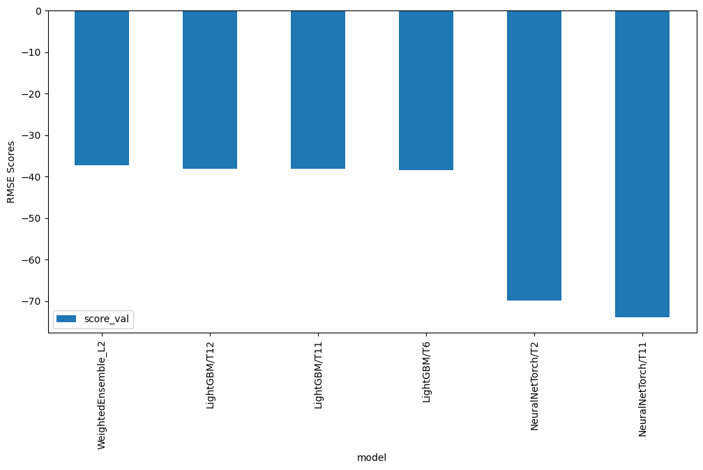

```python
import matplotlib.pyplot as plt
leaderboard_new_hpo_df.plot(kind="bar", x="model", y="score_val", figsize=(12, 6))
plt.ylabel("RMSE Scores")
plt.show()
```

```python
predictions_new_hpo = predictor_new_hpo.predict(test)
predictions_new_hpo.head()
```

```
0    18.428530
1     3.474496
2     0.446057
3     0.390254
4     0.424081
Name: count, dtype: float32
```

```python
predictions_new_hpo.describe()
```

```
count    6493.000000
mean      189.569183
std       173.467880
min       -23.499632
25%        46.705540
50%       147.292358
75%       282.617767
max       931.058105
Name: count, dtype: float64
```

```python
negative = predictions_new_hpo.apply(lambda x: 1 if x<0 else 0)
pred_pos_count = (negative==0).sum()
predneg_count = (negative==1).sum()
print("Total predictions                :", len(predictions_new_hpo.index))
print("Total positive prediction values :", pred_pos_count)
print("Total negative prediction values :", predneg_count)
```

```
Total predictions                : 6493
Total positive prediction values : 6398
Total negative prediction values : 95
```

```python
# Remember to set all negative values to zero
predictions_new_hpo[predictions_new_hpo<0] = 0

negative_pred_count = predictions_new_hpo.apply(lambda x: 1 if x<0 else 0)
pred_neg_count = (negative_pred_count==1).sum()
print(f"No. of negative predictions: {pred_neg_count}")
print("All negative values in the predictions (if there are any) are set to zero successfully.")
```

```
No. of negative predictions: 0
All negative values in the predictions (if there are any) are set to zero successfully.
```

```python
submission_new_hpo = pd.read_csv('sampleSubmission.csv', parse_dates = ['datetime'])
submission_new_hpo.head()
```

|  | datetime | count |
| --- | --- | --- |
| 0 | 2011-01-20 00:00:00 | 0 |
| 1 | 2011-01-20 01:00:00 | 0 |
| 2 | 2011-01-20 02:00:00 | 0 |
| 3 | 2011-01-20 03:00:00 | 0 |
| 4 | 2011-01-20 04:00:00 | 0 |

```python
# Same submitting predictions
submission_new_hpo["count"] = predictions_new_hpo
submission_new_hpo.to_csv("submission_new_hpo.csv", index=False)
```

```python
!kaggle competitions submit -c bike-sharing-demand -f submission_new_hpo.csv -m "new features with hyperparameters"
```

```
Successfully submitted to Bike Sharing Demand
```

```python
!kaggle competitions submissions -c bike-sharing-demand | tail -n +1 | head -n 6
```

```
fileName                     date                 description                          status    publicScore  privateScore
---------------------------  -------------------  -----------------------------------  --------  -----------  ------------
submission_new_hpo.csv       2024-05-09 22:05:41  new features with hyperparameters    complete  0.53293      0.53293
submission_new_features.csv  2024-05-09 22:00:02  new features                         complete  0.45087      0.45087
submission.csv               2024-05-09 21:48:21  first raw submission                 complete  1.80127      1.80127
submission.csv               2024-05-09 21:25:26  first raw submission                 complete  1.80538      1.80538
```

#### New Score of 0.53293

```python
# Step 6.1 hyper-parameter optimization
```

```python
eval_metric = 'root_mean_squared_error'
label = 'count'
ignored_columns = ["casual", "registered"]   # Ignored columns while training
train_data = train                           # 'casual' and 'registered' columns are already dropped/ignored
time_limit = 600                             # 10 minutes -> 600 seconds
presets = "optimize_for_deployment"
```

```python
import autogluon.core as ag
excluded_model_types = ['NN_TORCH']

gbm_options = [{'extra_trees': True,
                'num_boost_round': ag.space.Int(lower=100, upper=800, default=100),
                'num_leaves': ag.space.Int(lower=26, upper=66, default=36),  # number of leaves in trees (integer hyperparameter)
                'ag_args': {'name_suffix': 'XT'}}, {}, 'GBMLarge']

xt_options = {'criterion': 'squared_error', 'ag_args': {'name_suffix': 'MSE', 'problem_types': ['regression']}}
xgb_options = [{'objective': 'reg:squarederror', # 'reg:linear' is deprecated
                'eval_metric': 'rmse',
                'max_depth':ag.space.Int(lower=5, upper=8, default=6),
                'n_estimators': ag.space.Int(lower=100, upper=500, default=100),
                'eta':.3,
                'subsample': 1,
                'colsample_bytree': 1}]

hyperparameters = {
                   'GBM': gbm_options,
                   'XT': xt_options,
                   'XGB': xgb_options
                  }

num_trials = 20
search_strategy = 'auto'
scheduler = 'local'

hyperparameter_tune_kwargs = {
                            'num_trials': num_trials,
                            'scheduler' : scheduler,
                            'searcher': search_strategy,
                        }

predictor_new_hpo1 = TabularPredictor(label='count', problem_type='regression', eval_metric='root_mean_squared_error',
                                    learner_kwargs={'ignored_columns': ignored_columns}).fit(
                                                                         train_data=train,
                                                                         time_limit=time_limit,
                                                                         presets=presets,
                                                                         hyperparameters=hyperparameters,
                                                                         hyperparameter_tune_kwargs=hyperparameter_tune_kwargs,
                                                                         excluded_model_types=excluded_model_types,
                                                                         refit_full='best')
```

[output not shown]

[output not shown]

[output cut: 26 more lines]

```
	1.18s	 = Training   runtime
	0.23s	 = Validation runtime
Fitted model: LightGBMXT/T18 ...
	-43.5514	 = Validation score   (-root_mean_squared_error)
	1.46s	 = Training   runtime
	0.21s	 = Validation runtime
Fitted model: LightGBMXT/T19 ...
	-95.2959	 = Validation score   (-root_mean_squared_error)
	1.16s	 = Training   runtime
	0.13s	 = Validation runtime
Fitted model: LightGBMXT/T20 ...
	-41.1681	 = Validation score   (-root_mean_squared_error)
	1.42s	 = Training   runtime
	0.31s	 = Validation runtime
Hyperparameter tuning model: LightGBM ... Tuning model for up to 107.96s of the 567.28s of remaining time.
```

[output not shown]

[output not shown]

[output cut: 15 more lines]

```
Fitted model: LightGBM/T14 ...
	-38.6473	 = Validation score   (-root_mean_squared_error)
	6.91s	 = Training   runtime
	1.66s	 = Validation runtime
Fitted model: LightGBM/T15 ...
	-39.7006	 = Validation score   (-root_mean_squared_error)
	7.39s	 = Training   runtime
	3.23s	 = Validation runtime
Hyperparameter tuning model: ExtraTreesMSE ... Tuning model for up to 107.96s of the 456.5s of remaining time.
	No hyperparameter search space specified for ExtraTreesMSE. Skipping HPO. Will train one model based on the provided hyperparameters.
Fitted model: ExtraTreesMSE ...
	-40.044	 = Validation score   (-root_mean_squared_error)
	6.99s	 = Training   runtime
	0.84s	 = Validation runtime
Hyperparameter tuning model: XGBoost ... Tuning model for up to 107.96s of the 447.79s of remaining time.
```

[output not shown]

[output cut: 26 more lines]

```
	1.31s	 = Training   runtime
	0.07s	 = Validation runtime
Fitted model: XGBoost/T18 ...
	-40.3061	 = Validation score   (-root_mean_squared_error)
	0.64s	 = Training   runtime
	0.04s	 = Validation runtime
Fitted model: XGBoost/T19 ...
	-39.4014	 = Validation score   (-root_mean_squared_error)
	0.81s	 = Training   runtime
	0.06s	 = Validation runtime
Fitted model: XGBoost/T20 ...
	-61.2521	 = Validation score   (-root_mean_squared_error)
	1.68s	 = Training   runtime
	0.11s	 = Validation runtime
Fitting model: LightGBMLarge ... Training model for up to 107.96s of the 424.04s of remaining time.
```

```
[1000]	valid_set's rmse: 38.5198
```

[output not shown]

[output cut: 38 more lines]

[output not shown]

```python
predictor_new_hpo1.fit_summary()
```

```
*** Summary of fit() ***
Estimated performance of each model:
                 model  score_val  pred_time_val   fit_time  pred_time_val_marginal  fit_time_marginal  stack_level  can_infer  fit_order
0  WeightedEnsemble_L2 -37.096836       3.470681  25.638225                0.000480           0.442018            2       True          7
1         LightGBM/T12 -38.007447       0.874190   5.024637                0.874190           5.024637            1       True          3
2         LightGBM/T11 -38.050854       0.741910   4.393419                0.741910           4.393419            1       True          2
3          LightGBM/T6 -38.341211       0.820853   5.275774                0.820853           5.275774            1       True          1
4           XGBoost/T8 -39.145091       0.106841   2.142059                0.106841           2.142059            1       True          6
5           XGBoost/T3 -39.496929       0.086739   1.366357                0.086739           1.366357            1       True          5
6        ExtraTreesMSE -40.044046       0.839669   6.993962                0.839669           6.993962            1       True          4
Number of models trained: 7
Types of models trained:
{'XTModel', 'LGBModel', 'WeightedEnsembleModel', 'XGBoostModel'}
Bagging used: False
Multi-layer stack-ensembling used: False
Feature Metadata (Processed):
(raw dtype, special dtypes):
('category', [])  : 2 | ['season', 'weather']
('float', [])     : 3 | ['temp', 'atemp', 'windspeed']
('int', [])       : 4 | ['humidity', 'month', 'day', 'hour']
('int', ['bool']) : 3 | ['holiday', 'workingday', 'year']
*** End of fit() summary ***
```

```
{'model_types': {'LightGBM/T6': 'LGBModel',
  'LightGBM/T11': 'LGBModel',
  'LightGBM/T12': 'LGBModel',
  'ExtraTreesMSE': 'XTModel',
  'XGBoost/T3': 'XGBoostModel',
  'XGBoost/T8': 'XGBoostModel',
  'WeightedEnsemble_L2': 'WeightedEnsembleModel'},
 'model_performance': {'LightGBM/T6': -38.341210542502,
  'LightGBM/T11': -38.05085373744469,
  'LightGBM/T12': -38.00744712429987,
  'ExtraTreesMSE': -40.044045780804886,
  'XGBoost/T3': -39.496929124995106,
  'XGBoost/T8': -39.1450911447419,
  'WeightedEnsemble_L2': -37.096836039010064},
 'model_best': 'WeightedEnsemble_L2',
 'model_paths': {'LightGBM/T6': ['LightGBM', 'T6'],
  'LightGBM/T11': ['LightGBM', 'T11'],
  'LightGBM/T12': ['LightGBM', 'T12'],
  'ExtraTreesMSE': ['ExtraTreesMSE'],
  'XGBoost/T3': ['XGBoost', 'T3'],
  'XGBoost/T8': ['XGBoost', 'T8'],
  'WeightedEnsemble_L2': ['WeightedEnsemble_L2']},
 'model_fit_times': {'LightGBM/T6': 5.275773763656616,
  'LightGBM/T11': 4.39341926574707,
  'LightGBM/T12': 5.024636507034302,
  'ExtraTreesMSE': 6.993962049484253,
  'XGBoost/T3': 1.366356611251831,
  'XGBoost/T8': 2.142058849334717,
  'WeightedEnsemble_L2': 0.4420175552368164},
 'model_pred_times': {'LightGBM/T6': 0.8208527565002441,
  'LightGBM/T11': 0.7419099807739258,
  'LightGBM/T12': 0.8741903305053711,
  'ExtraTreesMSE': 0.8396687507629395,
  'XGBoost/T3': 0.08673858642578125,
  'XGBoost/T8': 0.10684084892272949,
  'WeightedEnsemble_L2': 0.0004801750183105469},
 'num_bag_folds': 0,
 'max_stack_level': 2,
 'model_hyperparams': {'LightGBM/T6': {'learning_rate': 0.017357968430552234,
   'feature_fraction': 0.9590196908843444,
```

[output cut: 55 more lines]

```
 1                0.874190           5.024637            1       True
 2                0.741910           4.393419            1       True
 3                0.820853           5.275774            1       True
 4                0.106841           2.142059            1       True
 5                0.086739           1.366357            1       True
 6                0.839669           6.993962            1       True

    fit_order
 0          7
 1          3
 2          2
 3          1
 4          6
 5          5
 6          4  }
```

```python
leaderboard_new_hpo1_df = pd.DataFrame(predictor_new_hpo1.leaderboard(silent=True))
leaderboard_new_hpo1_df
```

|  | model | score_val | pred_time_val | fit_time | pred_time_val_marginal | fit_time_marginal | stack_level | can_infer | fit_order |
| --- | --- | --- | --- | --- | --- | --- | --- | --- | --- |
| 0 | WeightedEnsemble_L2 | -37.096836 | 3.470681 | 25.638225 | 0.000480 | 0.442018 | 2 | True | 7 |
| 1 | LightGBM/T12 | -38.007447 | 0.874190 | 5.024637 | 0.874190 | 5.024637 | 1 | True | 3 |
| 2 | LightGBM/T11 | -38.050854 | 0.741910 | 4.393419 | 0.741910 | 4.393419 | 1 | True | 2 |
| 3 | LightGBM/T6 | -38.341211 | 0.820853 | 5.275774 | 0.820853 | 5.275774 | 1 | True | 1 |
| 4 | XGBoost/T8 | -39.145091 | 0.106841 | 2.142059 | 0.106841 | 2.142059 | 1 | True | 6 |
| 5 | XGBoost/T3 | -39.496929 | 0.086739 | 1.366357 | 0.086739 | 1.366357 | 1 | True | 5 |
| 6 | ExtraTreesMSE | -40.044046 | 0.839669 | 6.993962 | 0.839669 | 6.993962 | 1 | True | 4 |

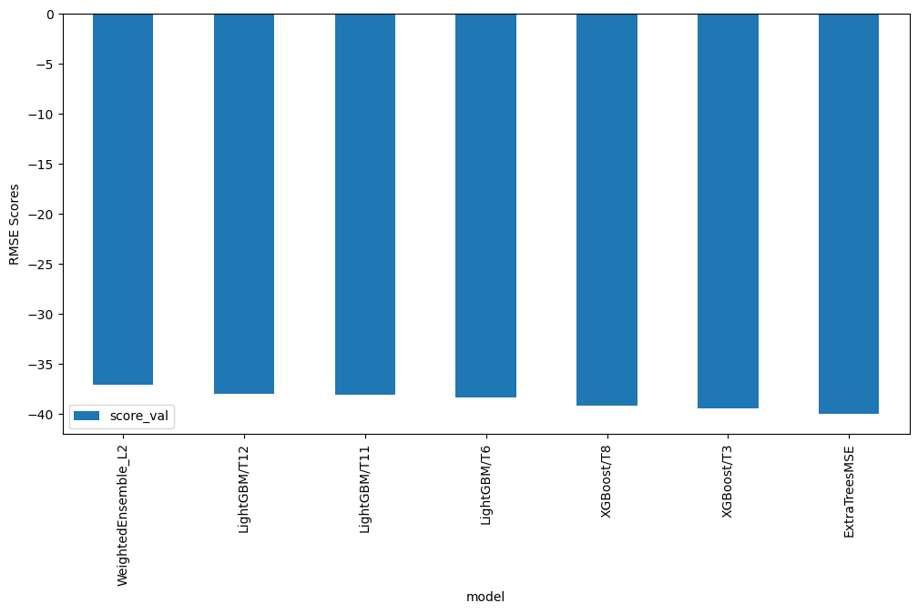

```python
import matplotlib.pyplot as plt
leaderboard_new_hpo1_df.plot(kind="bar", x="model", y="score_val", figsize=(12, 6))
plt.ylabel("RMSE Scores")
plt.show()
```

```python
predictions_new_hpo1 = predictor_new_hpo1.predict(test)
predictions_new_hpo1.head()
```

```
0    18.653828
1     3.388566
2     0.895045
3     0.489700
4     0.473539
Name: count, dtype: float32
```

```python
predictions_new_hpo1.describe()
```

```
count    6493.000000
mean      190.072784
std       173.637711
min       -17.612099
25%        46.944366
50%       148.408508
75%       283.170868
max       937.951050
Name: count, dtype: float64
```

```python
negative = predictions_new_hpo1.apply(lambda x: 1 if x<0 else 0)

pred_pos_count = (negative==0).sum()
predneg_count = (negative==1).sum()

print("Total predictions                :", len(predictions_new_hpo1.index))
print("Total positive prediction values :", pred_pos_count)
print("Total negative prediction values :", predneg_count)
```

```
Total predictions                : 6493
Total positive prediction values : 6427
Total negative prediction values : 66
```

```python
predictions_new_hpo1[predictions_new_hpo1<0] = 0    # (In case, if negative values exist in the predictions_new_hpo1, set them to 0)

# Rechecking, if no predictions are less than 0
negative_pred_count = predictions_new_hpo1.apply(lambda x: 1 if x<0 else 0)
predneg_count = (negative==1).sum()
print(f"No.of negative predictions: {pred_neg_count}")
print("All negative values in the predictions (if there are any) are set to zero successfully.")
```

```
No.of negative predictions: 0
All negative values in the predictions (if there are any) are set to zero successfully.
```

```python
submission_new_hpo1 = pd.read_csv('sampleSubmission.csv', parse_dates = ['datetime'])
submission_new_hpo1.head()
```

|  | datetime | count |
| --- | --- | --- |
| 0 | 2011-01-20 00:00:00 | 0 |
| 1 | 2011-01-20 01:00:00 | 0 |
| 2 | 2011-01-20 02:00:00 | 0 |
| 3 | 2011-01-20 03:00:00 | 0 |
| 4 | 2011-01-20 04:00:00 | 0 |

```python
submission_new_hpo1["count"] = predictions_new_hpo1
submission_new_hpo1.to_csv("submission_new_hpo1.csv", index=False)
```

```python
!kaggle competitions submit -c bike-sharing-demand -f submission_new_hpo1.csv -m "new features with hyperparameters 1"
```

```
Successfully submitted to Bike Sharing Demand
```

```python
!kaggle competitions submissions -c bike-sharing-demand | tail -n +1 | head -n 6
```

```
fileName                     date                 description                          status    publicScore  privateScore
---------------------------  -------------------  -----------------------------------  --------  -----------  ------------
submission_new_hpo1.csv      2024-05-09 22:09:53  new features with hyperparameters 1  complete  0.50829      0.50829
submission_new_hpo.csv       2024-05-09 22:05:41  new features with hyperparameters    complete  0.53293      0.53293
submission_new_features.csv  2024-05-09 22:00:02  new features                         complete  0.45087      0.45087
submission.csv               2024-05-09 21:48:21  first raw submission                 complete  1.80127      1.80127
```

```python
# step 6.2 hyper parameter optimization
```

```python
eval_metric = 'root_mean_squared_error'
label = 'count'
ignored_columns = ["casual", "registered"]   # Ignored columns while training
train_data = train                           # 'casual' and 'registered' columns are already dropped/ignored
time_limit = 600                             # 10 minutes -> 600 seconds
presets = "optimize_for_deployment"
```

```python
import autogluon.core as ag
excluded_model_types = ['NN_TORCH']


gbm_options = [{'extra_trees': True,
                'num_boost_round': ag.space.Int(lower=100, upper=800, default=100),
                'num_leaves': ag.space.Int(lower=26, upper=66, default=36),  # number of leaves in trees (integer hyperparameter)
                'ag_args': {'name_suffix': 'XT'}}, {}, 'GBMLarge']

xt_options = {'criterion': 'squared_error', 'ag_args': {'name_suffix': 'MSE', 'problem_types': ['regression']}}

xgb_options = [{'objective': 'reg:squarederror', # 'reg:linear' is deprecated
                'eval_metric': 'rmse',
                'max_depth':ag.space.Int(lower=5, upper=8, default=6),
                'n_estimators': ag.space.Int(lower=100, upper=500, default=100),
                'eta':.3,
                'subsample': 1,
                'colsample_bytree': 1}]
# Random Forest
rf_options = {'criterion': 'squared_error', 'ag_args': {'name_suffix': 'MSE', 'problem_types': ['regression']}}
# KNN
knn_options = [{'weights': 'uniform', 'ag_args': {'name_suffix': 'Uniform'}},
               {'weights': 'distance', 'ag_args': {'name_suffix': 'Distance'}}]  # default

hyperparameters = {
                   'GBM': gbm_options,
                   'KNN': knn_options,
                   'XT': xt_options,
                   'XGB': xgb_options,
                   'RF': rf_options
                  }


num_trials = 20
search_strategy = 'auto'
scheduler = 'local'

hyperparameter_tune_kwargs = {
                            'num_trials': num_trials,
                            'scheduler' : scheduler,
                            'searcher': search_strategy,
                        }


predictor_new_hpo2 = TabularPredictor(label='count', problem_type='regression', eval_metric='root_mean_squared_error',
                                    learner_kwargs={'ignored_columns': ignored_columns}).fit(
                                                                         train_data=train,
                                                                         time_limit=time_limit,
                                                                         presets=presets,
                                                                         hyperparameters=hyperparameters,
                                                                         hyperparameter_tune_kwargs=hyperparameter_tune_kwargs,
                                                                         excluded_model_types=excluded_model_types,
                                                                         refit_full='best')
```

[output not shown]

[output cut: 19 more lines]

```
Excluded models: [] (Specified by `excluded_model_types`)
Fitting 8 L1 models ...
Hyperparameter tuning model: KNeighborsUniform ... Tuning model for up to 67.48s of the 599.85s of remaining time.
	No hyperparameter search space specified for KNeighborsUniform. Skipping HPO. Will train one model based on the provided hyperparameters.
Fitted model: KNeighborsUniform ...
	-118.5766	 = Validation score   (-root_mean_squared_error)
	0.01s	 = Training   runtime
	0.11s	 = Validation runtime
Hyperparameter tuning model: KNeighborsDistance ... Tuning model for up to 67.48s of the 599.71s of remaining time.
	No hyperparameter search space specified for KNeighborsDistance. Skipping HPO. Will train one model based on the provided hyperparameters.
Fitted model: KNeighborsDistance ...
	-115.1894	 = Validation score   (-root_mean_squared_error)
	0.01s	 = Training   runtime
	0.15s	 = Validation runtime
Hyperparameter tuning model: LightGBMXT ... Tuning model for up to 67.48s of the 599.53s of remaining time.
```

[output not shown]

[output cut: 26 more lines]

```
	1.23s	 = Training   runtime
	0.14s	 = Validation runtime
Fitted model: LightGBMXT/T18 ...
	-43.5514	 = Validation score   (-root_mean_squared_error)
	1.33s	 = Training   runtime
	0.27s	 = Validation runtime
Fitted model: LightGBMXT/T19 ...
	-95.2959	 = Validation score   (-root_mean_squared_error)
	1.13s	 = Training   runtime
	0.17s	 = Validation runtime
Fitted model: LightGBMXT/T20 ...
	-41.1681	 = Validation score   (-root_mean_squared_error)
	1.36s	 = Training   runtime
	0.25s	 = Validation runtime
Hyperparameter tuning model: LightGBM ... Tuning model for up to 67.48s of the 568.12s of remaining time.
```

```
[1000]	valid_set's rmse: 38.7642
[2000]	valid_set's rmse: 38.4755
[1000]	valid_set's rmse: 39.1422
[1000]	valid_set's rmse: 39.5499
[2000]	valid_set's rmse: 38.4879
[3000]	valid_set's rmse: 38.2518
[4000]	valid_set's rmse: 38.233
[5000]	valid_set's rmse: 38.1722
[6000]	valid_set's rmse: 38.1922
[1000]	valid_set's rmse: 38.4946
[1000]	valid_set's rmse: 39.0428
[2000]	valid_set's rmse: 38.4416
[3000]	valid_set's rmse: 38.3747
[4000]	valid_set's rmse: 38.3085
[5000]	valid_set's rmse: 38.3253
[1000]	valid_set's rmse: 38.3854
[2000]	valid_set's rmse: 38.0515
```

[output not shown]

[output not shown]

[output cut: 26 more lines]

```
	1.41s	 = Training   runtime
	0.07s	 = Validation runtime
Fitted model: XGBoost/T18 ...
	-40.3061	 = Validation score   (-root_mean_squared_error)
	0.64s	 = Training   runtime
	0.04s	 = Validation runtime
Fitted model: XGBoost/T19 ...
	-39.4014	 = Validation score   (-root_mean_squared_error)
	0.97s	 = Training   runtime
	0.05s	 = Validation runtime
Fitted model: XGBoost/T20 ...
	-61.2521	 = Validation score   (-root_mean_squared_error)
	2.14s	 = Training   runtime
	0.12s	 = Validation runtime
Fitting model: LightGBMLarge ... Training model for up to 67.48s of the 455.05s of remaining time.
```

```
[1000]	valid_set's rmse: 38.5198
```

```
	-38.3822	 = Validation score   (-root_mean_squared_error)
	2.76s	 = Training   runtime
	0.27s	 = Validation runtime
Fitting model: WeightedEnsemble_L2 ... Training model for up to 360.0s of the 432.7s of remaining time.
	-37.2134	 = Validation score   (-root_mean_squared_error)
	0.58s	 = Training   runtime
	0.0s	 = Validation runtime
AutoGluon training complete, total runtime = 167.93s ... Best model: "WeightedEnsemble_L2"
Automatically performing refit_full as a post-fit operation (due to `.fit(..., refit_full=True)`
Refitting models via `predictor.refit_full` using all of the data (combined train and validation)...
	Models trained in this way will have the suffix "_FULL" and have NaN validation score.
	This process is not bound by time_limit, but should take less time than the original `predictor.fit` call.
	To learn more, refer to the `.refit_full` method docstring which explains how "_FULL" models differ from normal models.
Fitting 1 L1 models ...
Fitting model: LightGBM/T4_FULL ...
	11.37s	 = Training   runtime
Fitting 1 L1 models ...
Fitting model: LightGBM/T6_FULL ...
	4.09s	 = Training   runtime
Fitting 1 L1 models ...
Fitting model: LightGBM/T9_FULL ...
	11.13s	 = Training   runtime
Fitting 1 L1 models ...
Fitting model: LightGBM/T11_FULL ...
	4.13s	 = Training   runtime
Fitting 1 L1 models ...
Fitting model: ExtraTreesMSE_FULL ...
	8.37s	 = Training   runtime
Fitting 1 L1 models ...
Fitting model: XGBoost/T3_FULL ...
	1.08s	 = Training   runtime
Fitting 1 L1 models ...
Fitting model: XGBoost/T8_FULL ...
	1.3s	 = Training   runtime
Fitting 1 L1 models ...
Fitting model: LightGBMLarge_FULL ...
	2.21s	 = Training   runtime
Fitting model: WeightedEnsemble_L2_FULL | Skipping fit via cloning parent ...
	0.58s	 = Training   runtime
Refit complete, total runtime = 63.21s ... Best model: "WeightedEnsemble_L2"
```

[output cut: 43 more lines]

[output not shown]

```python
predictor_new_hpo2.fit_summary()
```

```
*** Summary of fit() ***
Estimated performance of each model:
                 model  score_val  pred_time_val   fit_time  pred_time_val_marginal  fit_time_marginal  stack_level  can_infer  fit_order
0  WeightedEnsemble_L2 -37.213437       8.994398  47.574079                0.000875           0.580631            2       True          9
1         LightGBM/T11 -38.050854       0.784622   4.993127                0.784622           4.993127            1       True          4
2          LightGBM/T4 -38.161981       2.338721  10.568768                2.338721          10.568768            1       True          1
3          LightGBM/T9 -38.300516       4.101117  13.794008                4.101117          13.794008            1       True          3
4          LightGBM/T6 -38.341211       0.612143   3.751647                0.612143           3.751647            1       True          2
5        LightGBMLarge -38.382190       0.270701   2.758208                0.270701           2.758208            1       True          8
6           XGBoost/T8 -39.145091       0.064579   3.208799                0.064579           3.208799            1       True          7
7           XGBoost/T3 -39.496929       0.055583   1.351672                0.055583           1.351672            1       True          6
8        ExtraTreesMSE -40.044046       0.766059   6.567218                0.766059           6.567218            1       True          5
Number of models trained: 9
Types of models trained:
{'XTModel', 'LGBModel', 'WeightedEnsembleModel', 'XGBoostModel'}
Bagging used: False
Multi-layer stack-ensembling used: False
Feature Metadata (Processed):
(raw dtype, special dtypes):
('category', [])  : 2 | ['season', 'weather']
('float', [])     : 3 | ['temp', 'atemp', 'windspeed']
('int', [])       : 4 | ['humidity', 'month', 'day', 'hour']
('int', ['bool']) : 3 | ['holiday', 'workingday', 'year']
*** End of fit() summary ***
```

```
{'model_types': {'LightGBM/T4': 'LGBModel',
  'LightGBM/T6': 'LGBModel',
  'LightGBM/T9': 'LGBModel',
  'LightGBM/T11': 'LGBModel',
  'ExtraTreesMSE': 'XTModel',
  'XGBoost/T3': 'XGBoostModel',
  'XGBoost/T8': 'XGBoostModel',
  'LightGBMLarge': 'LGBModel',
  'WeightedEnsemble_L2': 'WeightedEnsembleModel'},
 'model_performance': {'LightGBM/T4': -38.16198082161569,
  'LightGBM/T6': -38.341210542502,
  'LightGBM/T9': -38.30051598721774,
  'LightGBM/T11': -38.05085373744469,
  'ExtraTreesMSE': -40.044045780804886,
  'XGBoost/T3': -39.496929124995106,
  'XGBoost/T8': -39.1450911447419,
  'LightGBMLarge': -38.382190280507615,
  'WeightedEnsemble_L2': -37.21343652259016},
 'model_best': 'WeightedEnsemble_L2',
 'model_paths': {'LightGBM/T4': ['LightGBM', 'T4'],
  'LightGBM/T6': ['LightGBM', 'T6'],
  'LightGBM/T9': ['LightGBM', 'T9'],
  'LightGBM/T11': ['LightGBM', 'T11'],
  'ExtraTreesMSE': ['ExtraTreesMSE'],
  'XGBoost/T3': ['XGBoost', 'T3'],
  'XGBoost/T8': ['XGBoost', 'T8'],
  'LightGBMLarge': ['LightGBMLarge'],
  'WeightedEnsemble_L2': ['WeightedEnsemble_L2']},
 'model_fit_times': {'LightGBM/T4': 10.56876826286316,
  'LightGBM/T6': 3.751647472381592,
  'LightGBM/T9': 13.794008255004883,
  'LightGBM/T11': 4.99312686920166,
  'ExtraTreesMSE': 6.567217826843262,
  'XGBoost/T3': 1.3516724109649658,
  'XGBoost/T8': 3.208798885345459,
  'LightGBMLarge': 2.7582082748413086,
  'WeightedEnsemble_L2': 0.5806307792663574},
 'model_pred_times': {'LightGBM/T4': 2.3387207984924316,
  'LightGBM/T6': 0.6121430397033691,
  'LightGBM/T9': 4.101116895675659,
```

[output cut: 79 more lines]

```
 5                0.270701           2.758208            1       True
 6                0.064579           3.208799            1       True
 7                0.055583           1.351672            1       True
 8                0.766059           6.567218            1       True

    fit_order
 0          9
 1          4
 2          1
 3          3
 4          2
 5          8
 6          7
 7          6
 8          5  }
```

```python
leaderboard_new_hpo2_df = pd.DataFrame(predictor_new_hpo2.leaderboard(silent=True))
leaderboard_new_hpo2_df
```

|  | model | score_val | pred_time_val | fit_time | pred_time_val_marginal | fit_time_marginal | stack_level | can_infer | fit_order |
| --- | --- | --- | --- | --- | --- | --- | --- | --- | --- |
| 0 | WeightedEnsemble_L2 | -37.213437 | 8.994398 | 47.574079 | 0.000875 | 0.580631 | 2 | True | 9 |
| 1 | LightGBM/T11 | -38.050854 | 0.784622 | 4.993127 | 0.784622 | 4.993127 | 1 | True | 4 |
| 2 | LightGBM/T4 | -38.161981 | 2.338721 | 10.568768 | 2.338721 | 10.568768 | 1 | True | 1 |
| 3 | LightGBM/T9 | -38.300516 | 4.101117 | 13.794008 | 4.101117 | 13.794008 | 1 | True | 3 |
| 4 | LightGBM/T6 | -38.341211 | 0.612143 | 3.751647 | 0.612143 | 3.751647 | 1 | True | 2 |
| 5 | LightGBMLarge | -38.382190 | 0.270701 | 2.758208 | 0.270701 | 2.758208 | 1 | True | 8 |
| 6 | XGBoost/T8 | -39.145091 | 0.064579 | 3.208799 | 0.064579 | 3.208799 | 1 | True | 7 |
| 7 | XGBoost/T3 | -39.496929 | 0.055583 | 1.351672 | 0.055583 | 1.351672 | 1 | True | 6 |
| 8 | ExtraTreesMSE | -40.044046 | 0.766059 | 6.567218 | 0.766059 | 6.567218 | 1 | True | 5 |

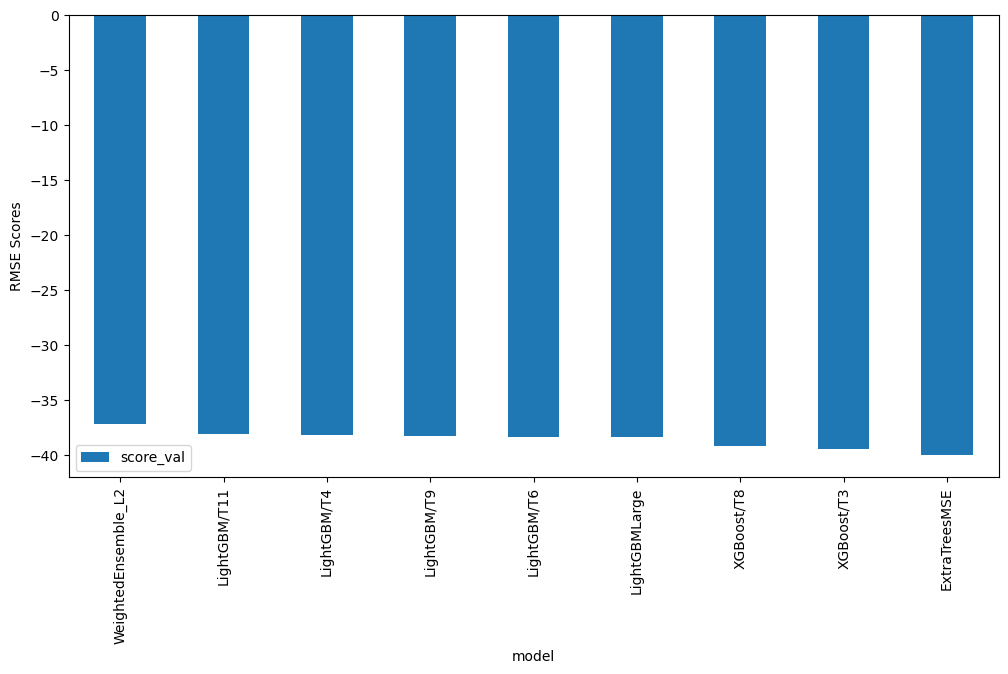

```python
import matplotlib.pyplot as plt
leaderboard_new_hpo2_df.plot(kind="bar", x="model", y="score_val", figsize=(12, 6))
plt.ylabel("RMSE Scores")
plt.show()
```

```python
predictions_new_hpo2 = predictor_new_hpo2.predict(test)
predictions_new_hpo2.head()
```

```
0    17.514278
1     3.361670
2     0.917843
3     0.640412
4     0.601965
Name: count, dtype: float32
```

```python
predictions_new_hpo2.describe()
```

```
count    6493.000000
mean      190.417328
std       173.737595
min       -16.765165
25%        46.617218
50%       149.188919
75%       283.315857
max       939.066406
Name: count, dtype: float64
```

```python
negative = predictions_new_hpo2.apply(lambda x: 1 if x<0 else 0)

pred_pos_count = (negative==0).sum()
predneg_count = (negative==1).sum()

print("Total predictions                :", len(predictions_new_hpo2.index))
print("Total positive prediction values :", pred_pos_count)
print("Total negative prediction values :", predneg_count)
```

```
Total predictions                : 6493
Total positive prediction values : 6442
Total negative prediction values : 51
```

```python
predictions_new_hpo2[predictions_new_hpo2<0] = 0
negative_pred_count = predictions_new_hpo2.apply(lambda x: 1 if x<0 else 0)
pred_neg_count = (negative_pred_count==1).sum()
print(f"No. of negative predictions: {pred_neg_count}")
print("All negative values in the predictions (if there are any) are set to zero successfully.")
```

```
No. of negative predictions: 0
All negative values in the predictions (if there are any) are set to zero successfully.
```

```python
submission_new_hpo2 = pd.read_csv('sampleSubmission.csv', parse_dates = ['datetime'])
submission_new_hpo2.head()
```

|  | datetime | count |
| --- | --- | --- |
| 0 | 2011-01-20 00:00:00 | 0 |
| 1 | 2011-01-20 01:00:00 | 0 |
| 2 | 2011-01-20 02:00:00 | 0 |
| 3 | 2011-01-20 03:00:00 | 0 |
| 4 | 2011-01-20 04:00:00 | 0 |

```python
submission_new_hpo2["count"] = predictions_new_hpo2
submission_new_hpo2.to_csv("submission_new_hpo2.csv", index=False)
```

```python
!kaggle competitions submit -c bike-sharing-demand -f submission_new_hpo2.csv -m "new features with hyperparameters 2"
```

```
Successfully submitted to Bike Sharing Demand
```

```python
!kaggle competitions submissions -c bike-sharing-demand | tail -n +1 | head -n 7
```

```
fileName                     date                 description                          status    publicScore  privateScore
---------------------------  -------------------  -----------------------------------  --------  -----------  ------------
submission_new_hpo2.csv      2024-05-09 22:14:38  new features with hyperparameters 2  complete  0.4988       0.4988
submission_new_hpo1.csv      2024-05-09 22:09:53  new features with hyperparameters 1  complete  0.50829      0.50829
submission_new_hpo.csv       2024-05-09 22:05:41  new features with hyperparameters    complete  0.53293      0.53293
submission_new_features.csv  2024-05-09 22:00:02  new features                         complete  0.45087      0.45087
submission.csv               2024-05-09 21:48:21  first raw submission                 complete  1.80127      1.80127
```

## Step 7: Write a Report

### Refer to the markdown file for the full report

### Creating plots and table for report

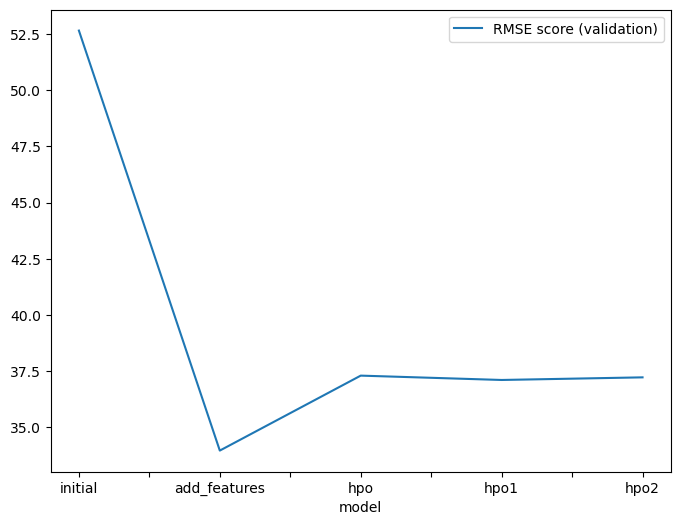

```python
# Taking the top model score from each training run and creating a line plot to show improvement
# You can create these in the notebook and save them to PNG or use some other tool (e.g. google sheets, excel)
fig = pd.DataFrame(
    {
        "model": ["initial", "add_features", "hpo", "hpo1", "hpo2"],
        "RMSE score (validation)": [52.662210, 33.951163, 37.290631, 37.096836, 37.213437]
    }
).plot(x="model", y="RMSE score (validation)", figsize=(8, 6)).get_figure()
fig.savefig('model_train_score.png')
```

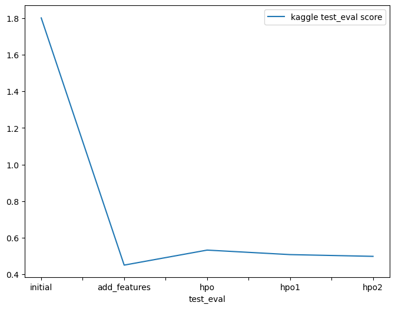

```python
import pandas as pd
import matplotlib.pyplot as plt

df = pd.DataFrame({
    "test_eval": ["initial", "add_features", "hpo", "hpo1", "hpo2"],
    "kaggle test_eval score": [1.80127, 0.45087, 0.53293, 0.50829, 0.4988]
})

fig = df.plot(x="test_eval", y="kaggle test_eval score", figsize=(8, 6)).get_figure()
# Create the "img" directory if it doesn't exist
import os
if not os.path.exists('img'):
    os.makedirs('img')

fig.savefig('img/model_test_score.png')
```

### Hyperparameter table

```python
# The 3 hyperparameters we tuned with the kaggle score as the result
pd.DataFrame({
    "model": ["initial", "add_features", "hpo (top-hpo-model: hpo2)"],
    "hpo1": ["prescribed_values", "prescribed_values", "Tree-Based Models: (GBM, XT, XGB & RF)"],
    "hpo2": ["prescribed_values", "prescribed_values", "KNN"],
    "hpo3": ["presets: 'high quality' (auto_stack=True)", "presets: 'high quality' (auto_stack=True)", "presets: 'optimize_for_deployment"],
    "score": [1.80127, 0.45087, 0.4988]
})
```

|  | model | hpo1 | hpo2 | hpo3 | score |
| --- | --- | --- | --- | --- | --- |
| 0 | initial | prescribed_values | prescribed_values | presets: 'high quality' (auto_stack=True) | 1.80127 |
| 1 | add_features | prescribed_values | prescribed_values | presets: 'high quality' (auto_stack=True) | 0.45087 |
| 2 | hpo (top-hpo-model: hpo2) | Tree-Based Models: (GBM, XT, XGB & RF) | KNN | presets: 'optimize_for_deployment | 0.49880 |